# Project Report

### Linear, Registered, atemp

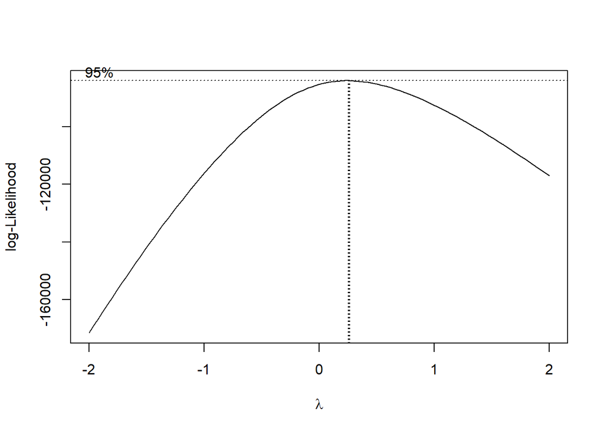

```r
bc.lra<-boxcox(registered ~. - casual,data = x.la )
```

```r
lambda.lra <- bc.lra$x[which.max(bc.lra$y)]
model.lra <- lm(((registered^lambda.lra-1)/lambda.lra) ~ . - casual, data = x.la)

summary(model.lra)
```

```
##
## Call:
## lm(formula = ((registered^lambda.lra - 1)/lambda.lra) ~ . - casual,
##     data = x.la)
##
## Residuals:
##    Min     1Q Median     3Q    Max
## -8.738 -2.137 -0.076  1.913 10.049
##
## Coefficients:
##              Estimate Std. Error t value Pr(>|t|)
## (Intercept)  3.232732   0.145581  22.206  < 2e-16 ***
## yr           1.532771   0.045924  33.376  < 2e-16 ***
## mnth         0.125034   0.006934  18.032  < 2e-16 ***
## hr           0.263299   0.003498  75.270  < 2e-16 ***
## holiday     -0.545475   0.141910  -3.844 0.000122 ***
## weekday      0.048812   0.011461   4.259 2.06e-05 ***
## workingday   0.560041   0.050828  11.018  < 2e-16 ***
## weathersit  -0.049372   0.040387  -1.222 0.221542
## atemp        6.114226   0.138602  44.114  < 2e-16 ***
## hum         -3.880228   0.145840 -26.606  < 2e-16 ***
## windspeed    0.993795   0.199262   4.987 6.18e-07 ***
## ---
## Signif. codes:  0 '***' 0.001 '**' 0.01 '*' 0.05 '.' 0.1 ' ' 1
##
## Residual standard error: 3.01 on 17368 degrees of freedom
## Multiple R-squared:  0.4553, Adjusted R-squared:  0.455
## F-statistic:  1452 on 10 and 17368 DF,  p-value: < 2.2e-16
```

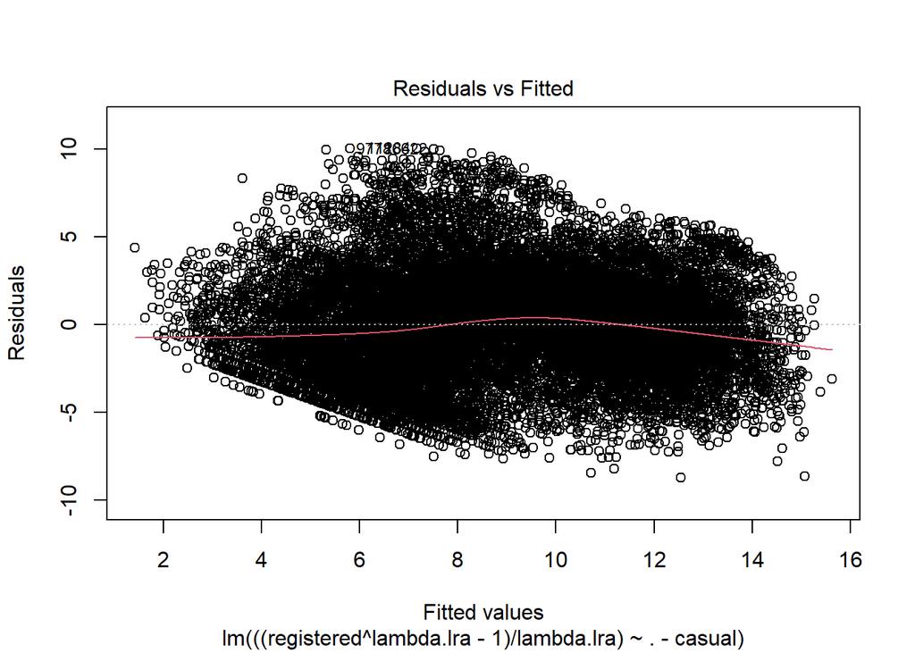

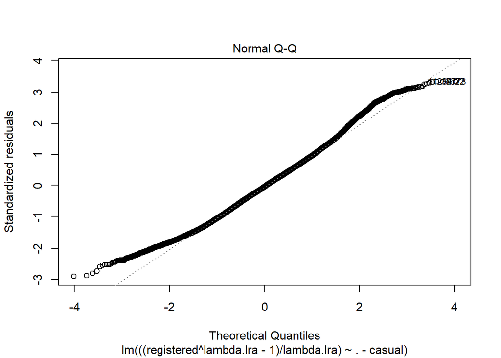

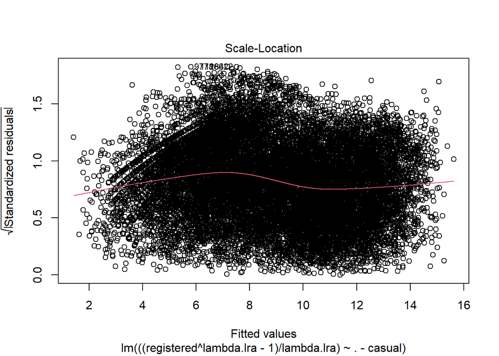

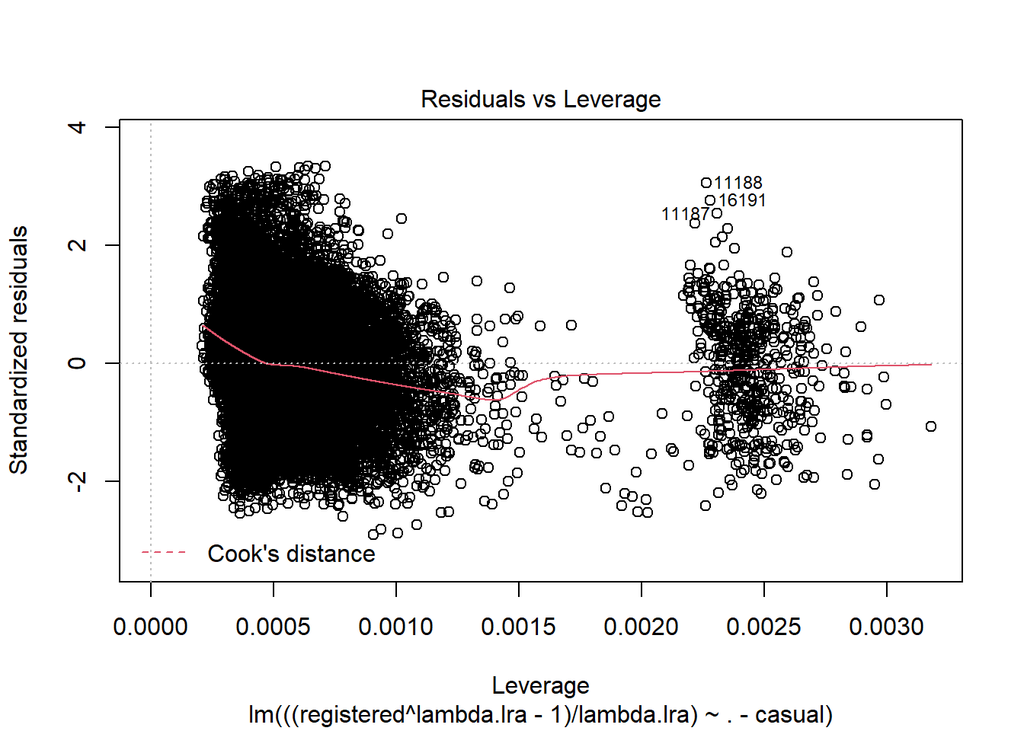

```r
plot(model.lra)
```

### Linear, Registered, temp

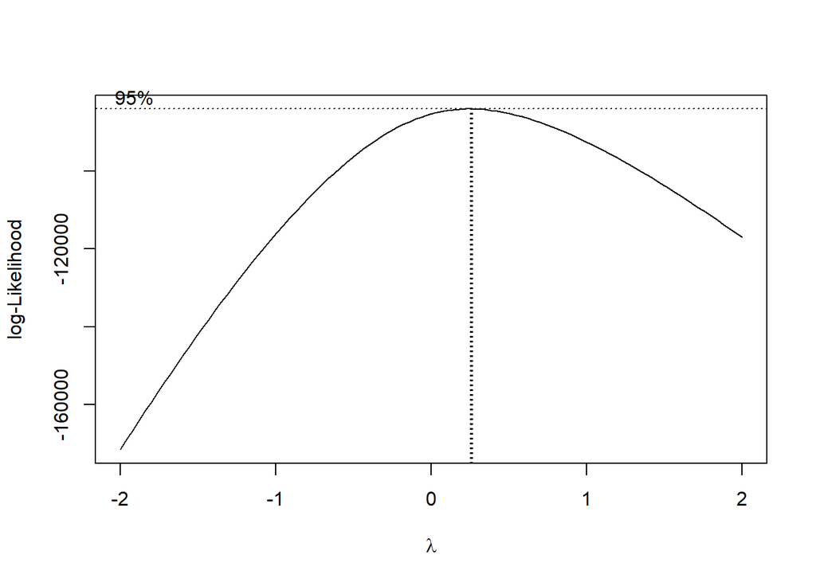

```r
bc.lrt<-boxcox(registered ~. - casual,data = x.lt )
```

```r
lambda.lrt <- bc.lrt$x[which.max(bc.lrt$y)]
model.lrt <- lm(((registered^lambda.lrt-1)/lambda.lrt) ~ . - casual, data = x.lt)

summary(model.lrt)
```

```
##
## Call:
## lm(formula = ((registered^lambda.lrt - 1)/lambda.lrt) ~ . - casual,
##     data = x.lt)
##
## Residuals:
##     Min      1Q  Median      3Q     Max
## -8.5905 -2.1334 -0.0701  1.9220 10.2001
##
## Coefficients:
##              Estimate Std. Error t value Pr(>|t|)
## (Intercept)  3.506200   0.143600  24.416  < 2e-16 ***
## yr           1.531287   0.045981  33.303  < 2e-16 ***
## mnth         0.125825   0.006942  18.125  < 2e-16 ***
## hr           0.264163   0.003500  75.467  < 2e-16 ***
## holiday     -0.576328   0.142066  -4.057 5.00e-05 ***
## weekday      0.045311   0.011474   3.949 7.88e-05 ***
## workingday   0.557188   0.050894  10.948  < 2e-16 ***
## weathersit  -0.061799   0.040415  -1.529 0.126250
## temp         5.385563   0.123565  43.585  < 2e-16 ***
## hum         -3.823658   0.146048 -26.181  < 2e-16 ***
## windspeed    0.678974   0.199240   3.408 0.000656 ***
## ---
## Signif. codes:  0 '***' 0.001 '**' 0.01 '*' 0.05 '.' 0.1 ' ' 1
##
## Residual standard error: 3.014 on 17368 degrees of freedom
## Multiple R-squared:  0.454,  Adjusted R-squared:  0.4537
## F-statistic:  1444 on 10 and 17368 DF,  p-value: < 2.2e-16
```

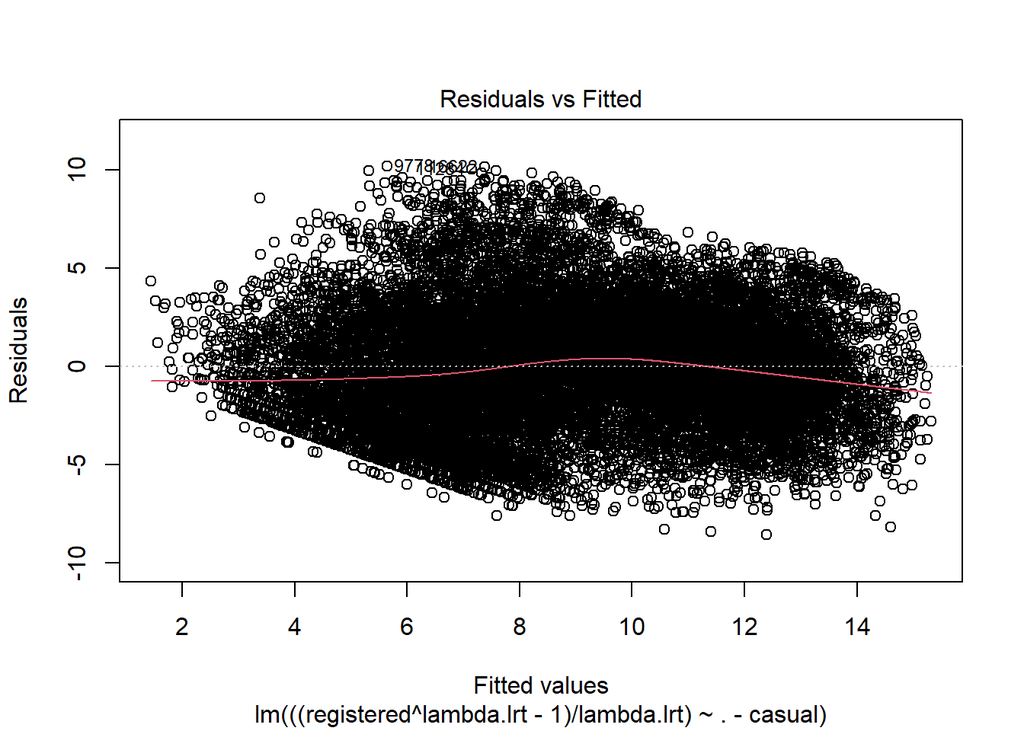

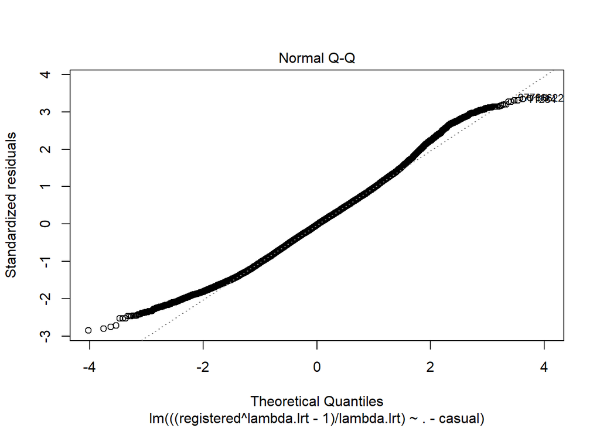

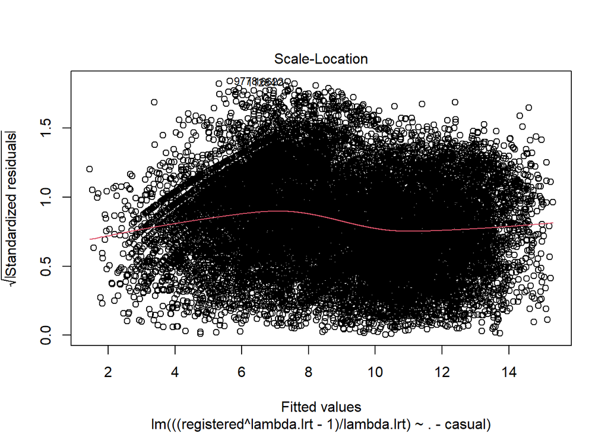

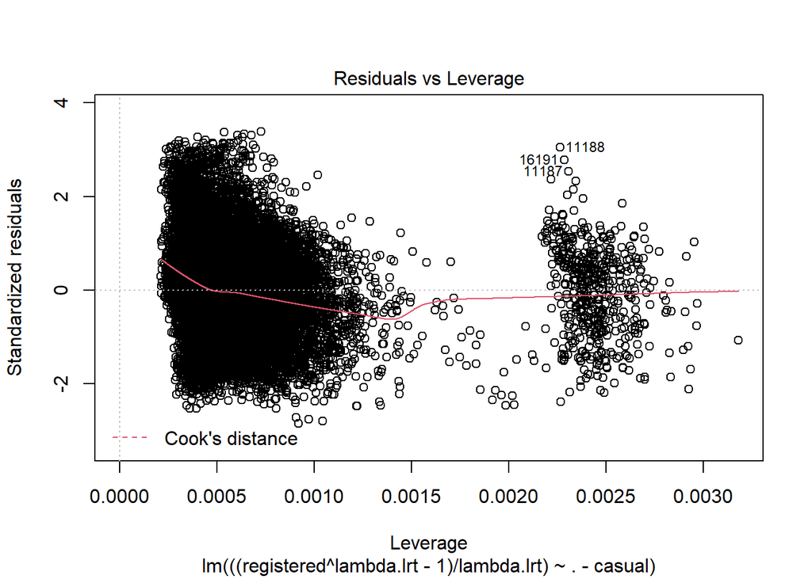

```r
plot(model.lrt)
```

### Quadratic, Registered, atemp

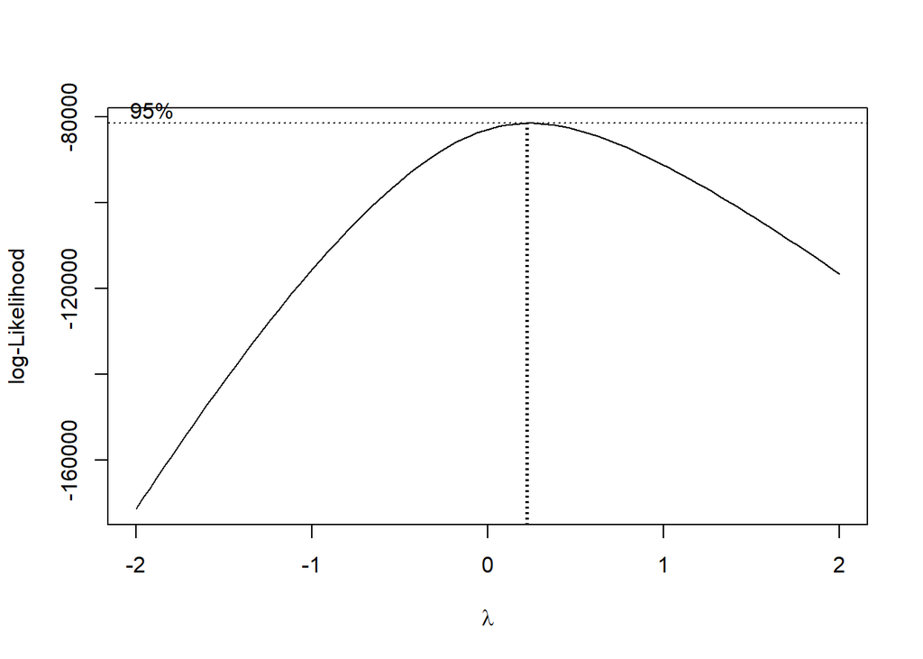

```r
bc.qra<-boxcox(registered ~. - casual,data = x.qa )
```

```r
lambda.qra <- bc.qra$x[which.max(bc.qra$y)]
model.qra <- lm(((registered^lambda.qra-1)/lambda.qra) ~ . - casual, data = x.qa)

summary(model.qra)
```

```
##
## Call:
## lm(formula = ((registered^lambda.qra - 1)/lambda.qra) ~ . - casual,
##     data = x.qa)
##
## Residuals:
##     Min      1Q  Median      3Q     Max
## -6.3220 -1.4541 -0.1572  1.3007  7.4344
##
## Coefficients:
##               Estimate Std. Error t value Pr(>|t|)
## (Intercept) -3.7348506  0.2394169 -15.600  < 2e-16 ***
## yr           1.2748670  0.0335308  38.021  < 2e-16 ***
## mnth         0.1542722  0.0381936   4.039 5.39e-05 ***
## hr           0.9411868  0.0100139  93.988  < 2e-16 ***
## holiday     -0.3944728  0.1226797  -3.215   0.0013 **
## weekday      0.0032449  0.0720262   0.045   0.9641
## workingday   0.5027391  0.0915872   5.489 4.09e-08 ***
## weathersit   1.3116109  0.1651339   7.943 2.10e-15 ***
## atemp       10.8433505  0.5769794  18.793  < 2e-16 ***
## hum          3.0759822  0.5404868   5.691 1.28e-08 ***
## windspeed    1.9754623  0.3631280   5.440 5.40e-08 ***
## mnth2       -0.0057174  0.0027714  -2.063   0.0391 *
## hr2         -0.0302675  0.0004077 -74.232  < 2e-16 ***
## weekday2     0.0079872  0.0119009   0.671   0.5021
## weathersit2 -0.4488113  0.0449680  -9.981  < 2e-16 ***
## atemp2      -7.2843287  0.5636620 -12.923  < 2e-16 ***
## hum2        -3.8460091  0.4363814  -8.813  < 2e-16 ***
## windspeed2  -4.0753004  0.7412856  -5.498 3.90e-08 ***
## ---
## Signif. codes:  0 '***' 0.001 '**' 0.01 '*' 0.05 '.' 0.1 ' ' 1
##
## Residual standard error: 2.18 on 17361 degrees of freedom
## Multiple R-squared:  0.5958, Adjusted R-squared:  0.5954
## F-statistic:  1505 on 17 and 17361 DF,  p-value: < 2.2e-16
```

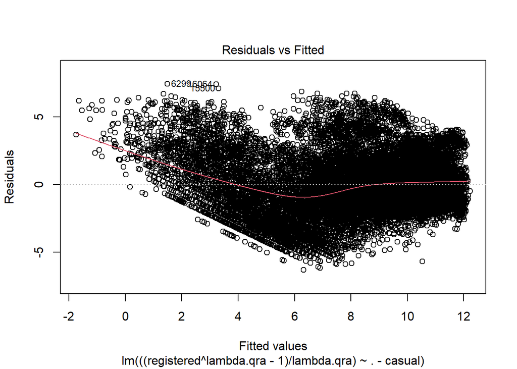

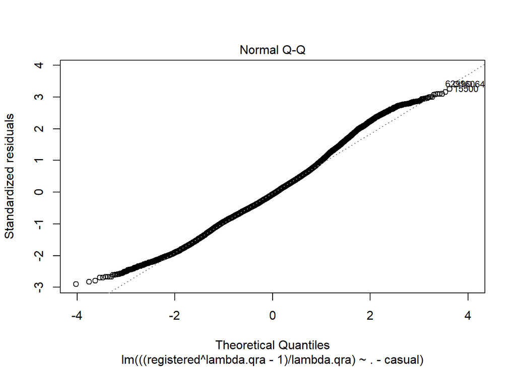

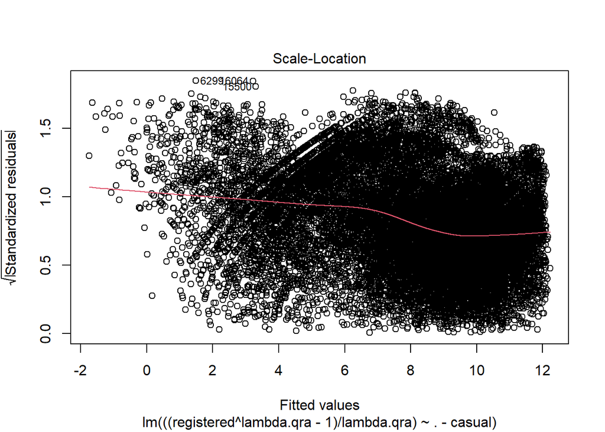

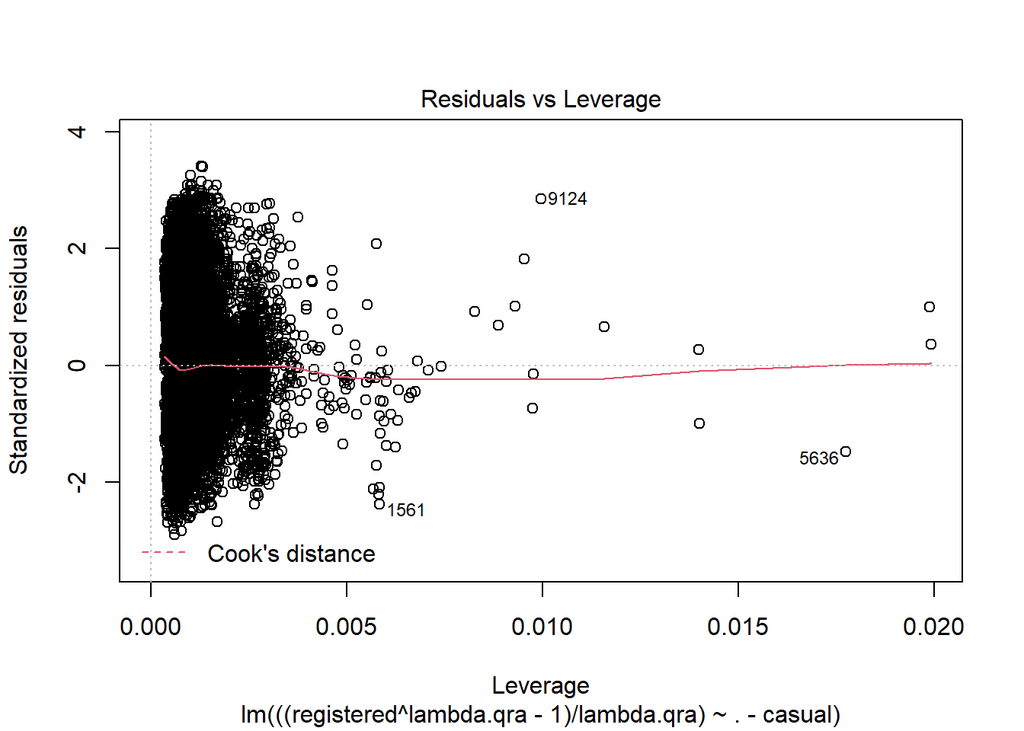

```r
plot(model.qra)
```

### Quadratic, Registered, temp

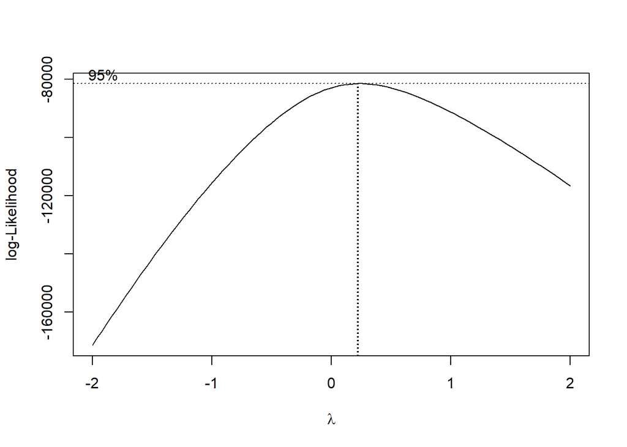

```r
bc.qrt<-boxcox(registered ~. - casual,data = x.qt )
```

```r
lambda.qrt <- bc.qrt$x[which.max(bc.qrt$y)]
model.qrt <- lm(((registered^lambda.qrt-1)/lambda.qrt) ~ . - casual, data = x.qt)

summary(model.qrt)
```

```
##
## Call:
## lm(formula = ((registered^lambda.qrt - 1)/lambda.qrt) ~ . - casual,
##     data = x.qt)
##
## Residuals:
##    Min     1Q Median     3Q    Max
## -6.385 -1.450 -0.158  1.296  7.414
##
## Coefficients:
##               Estimate Std. Error t value Pr(>|t|)
## (Intercept) -3.4246997  0.2302624 -14.873  < 2e-16 ***
## yr           1.2635872  0.0335895  37.619  < 2e-16 ***
## mnth         0.0978685  0.0399857   2.448 0.014392 *
## hr           0.9418151  0.0100155  94.036  < 2e-16 ***
## holiday     -0.4194547  0.1227005  -3.419 0.000631 ***
## weekday     -0.0007713  0.0720310  -0.011 0.991457
## workingday   0.5005068  0.0915864   5.465 4.70e-08 ***
## weathersit   1.2922896  0.1651873   7.823 5.44e-15 ***
## temp        10.2230247  0.5226558  19.560  < 2e-16 ***
## hum          3.1819494  0.5388788   5.905 3.60e-09 ***
## windspeed    1.4481602  0.3627367   3.992 6.57e-05 ***
## mnth2       -0.0016283  0.0028970  -0.562 0.574076
## hr2         -0.0303105  0.0004078 -74.321  < 2e-16 ***
## weekday2     0.0083812  0.0119012   0.704 0.481298
## weathersit2 -0.4442248  0.0449828  -9.875  < 2e-16 ***
## temp2       -6.5275937  0.4712179 -13.853  < 2e-16 ***
## hum2        -3.9451794  0.4340439  -9.089  < 2e-16 ***
## windspeed2  -3.8355011  0.7412619  -5.174 2.31e-07 ***
## ---
## Signif. codes:  0 '***' 0.001 '**' 0.01 '*' 0.05 '.' 0.1 ' ' 1
##
## Residual standard error: 2.18 on 17361 degrees of freedom
## Multiple R-squared:  0.5958, Adjusted R-squared:  0.5954
## F-statistic:  1505 on 17 and 17361 DF,  p-value: < 2.2e-16
```

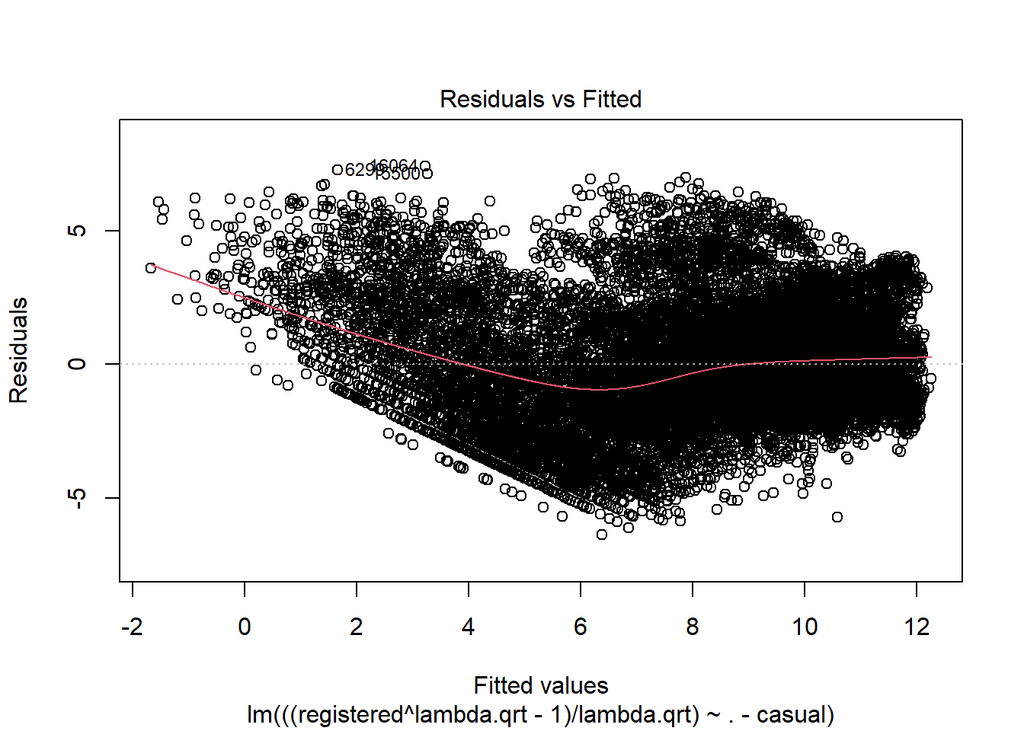

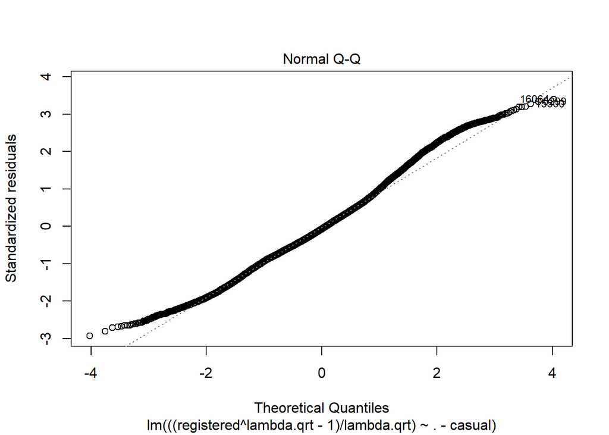

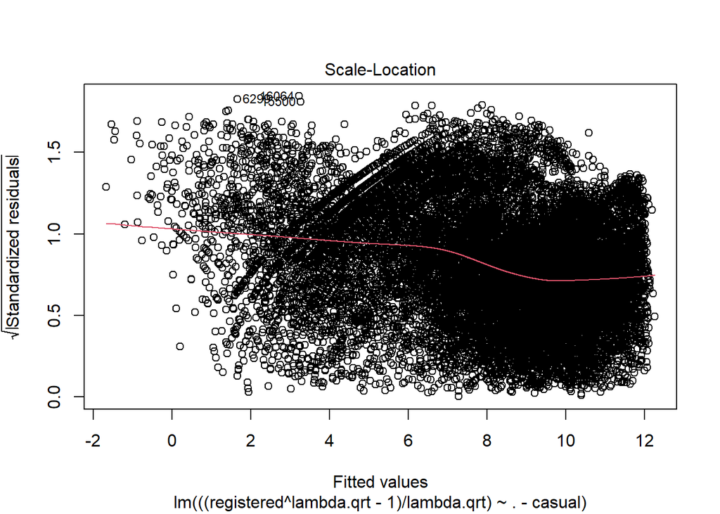

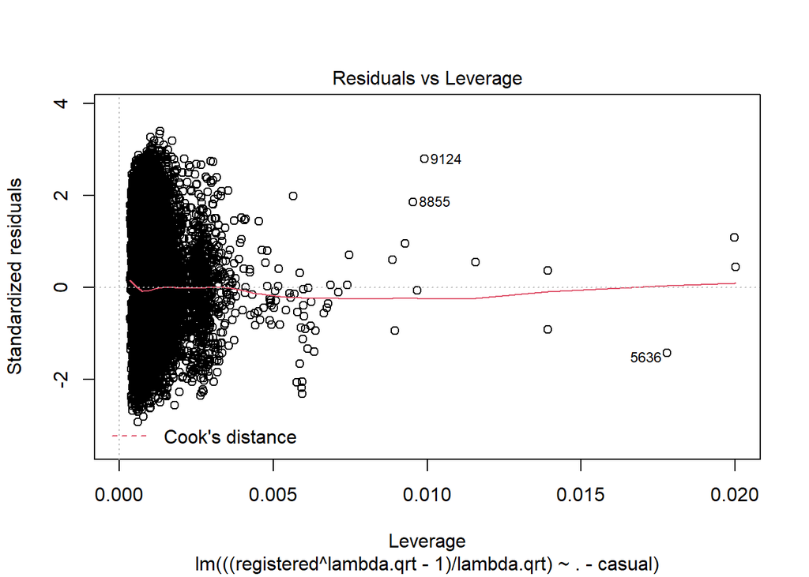

```r
plot(model.qrt)
```

## VARIABLE SELECTION

### Linear, Casual, atemp

```r
x.la <- subset(df, select = - c(season,temp))
x.la$casual <- x.la$casual+1
x.la$registered <- x.la$registered+1
x.la$casual <-(x.la$casual^lambda.lca-1)/lambda.lca
y.la <- x.la$casual
X.la <- subset(x.la, select = - c(casual,registered))
X.la <- as.matrix(X.la)

## LASSO
cross.validation.lca <- cv.glmnet(X.la, y.la, alpha = 1,type.measure = "mse")
optimal.lambda.lca <- cross.validation.lca$lambda.min
lm.lasso.optimal.lca <-glmnet(X.la, y.la,
                   lambda = optimal.lambda.lca,
                   alpha = 1, #alpha=1 is the LASSO penalty
                   family = 'gaussian')

coef(lm.lasso.optimal.lca)
```

```
## 11 x 1 sparse Matrix of class "dgCMatrix"
##                      s0
## (Intercept)  1.30838457
## yr           0.29564564
## mnth         0.03393871
## hr           0.09345626
## holiday     -0.28545720
## weekday      0.01410383
## workingday  -0.95083070
## weathersit   0.00691440
## atemp        5.65296297
## hum         -2.61495061
## windspeed    0.29899991
```

```r
## Backwards Selection
X.la<- subset(X.la,select = - weathersit)

summary(lm(y.la~X.la))
```

```
##
## Call:
## lm(formula = y.la ~ X.la)
##
## Residuals:
##     Min      1Q  Median      3Q     Max
## -4.4634 -0.8313  0.0704  0.8722  4.1329
##
## Coefficients:
##                 Estimate Std. Error t value Pr(>|t|)
## (Intercept)     1.295428   0.059281  21.852  < 2e-16 ***
## X.layr          0.301809   0.018739  16.106  < 2e-16 ***
## X.lamnth        0.034882   0.002828  12.334  < 2e-16 ***
## X.lahr          0.093807   0.001419  66.125  < 2e-16 ***
## X.laholiday    -0.309139   0.057931  -5.336 9.60e-08 ***
## X.laweekday     0.015521   0.004678   3.318 0.000908 ***
## X.laworkingday -0.959577   0.020728 -46.294  < 2e-16 ***
## X.laatemp       5.663910   0.056365 100.486  < 2e-16 ***
## X.lahum        -2.613001   0.053057 -49.249  < 2e-16 ***
## X.lawindspeed   0.327768   0.080375   4.078 4.56e-05 ***
## ---
## Signif. codes:  0 '***' 0.001 '**' 0.01 '*' 0.05 '.' 0.1 ' ' 1
##
## Residual standard error: 1.229 on 17369 degrees of freedom
## Multiple R-squared:  0.6015, Adjusted R-squared:  0.6013
## F-statistic:  2913 on 9 and 17369 DF,  p-value: < 2.2e-16
```

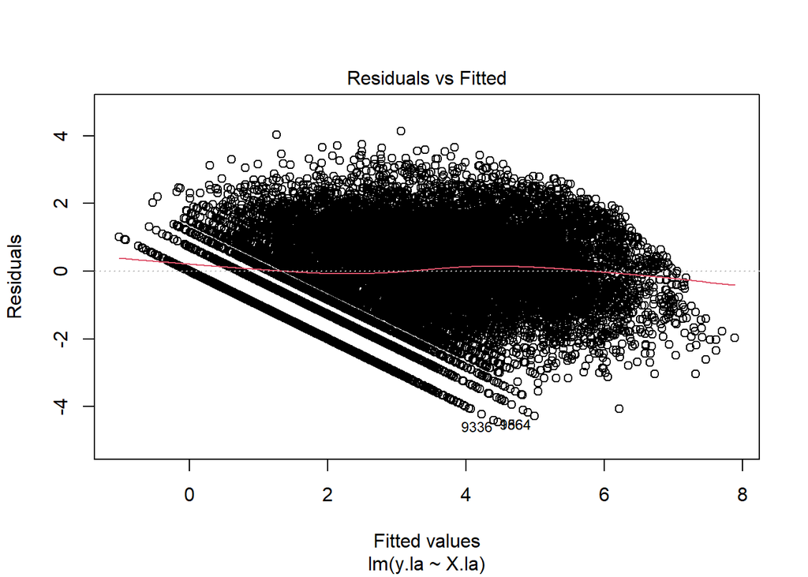

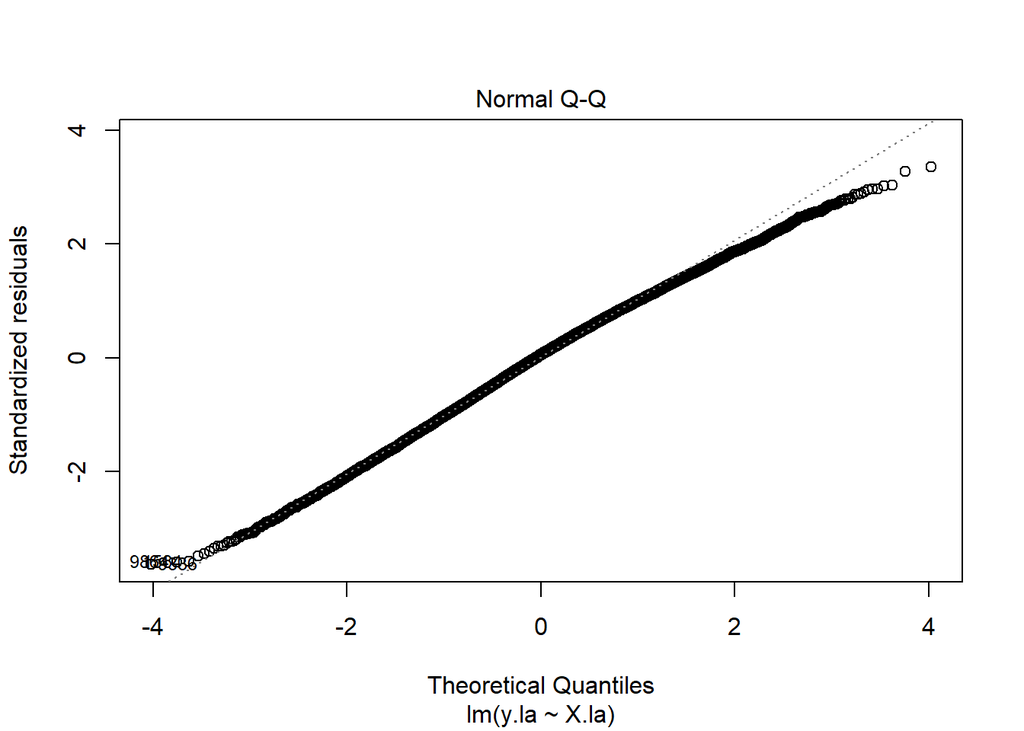

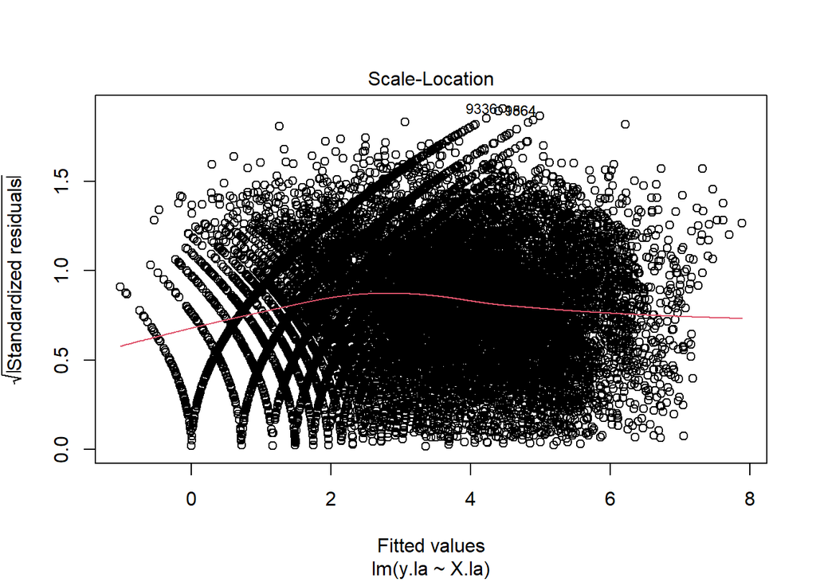

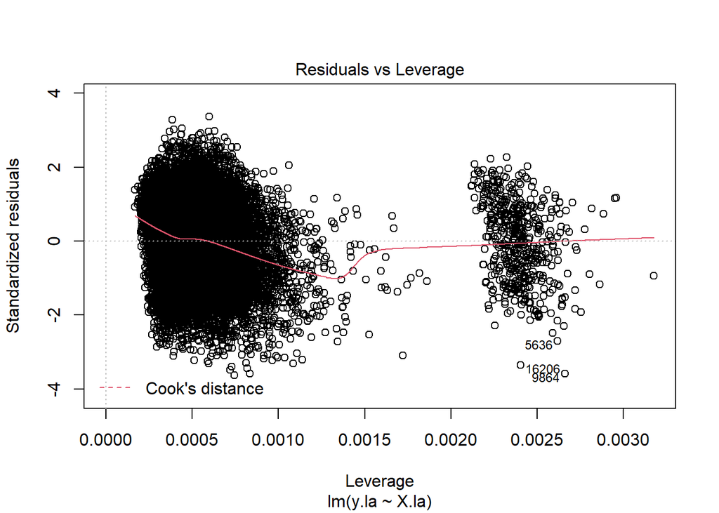

```r
plot(lm(y.la~X.la))
```

```r
## PRESS
PRESS(lm(y.la~X.la))
```

```
## [1] 26256.79
```

LASSO: All variables are significant

Backwards Selection: All except ‘weathersit’

### Linear, Casual, temp

```r
x.lt <- subset(df, select = - c(season,atemp))
x.lt$casual <- x.lt$casual+1
x.lt$registered <- x.lt$registered+1
x.lt$casual <-(x.lt$casual^lambda.lct-1)/lambda.lct
y.lt <- x.lt$casual
X.lt <- subset(x.lt, select = - c(casual,registered))
X.lt <- as.matrix(X.lt)

## LASSO
cross.validation.lct <- cv.glmnet(X.lt, y.lt, alpha = 1,type.measure = "mse")
optimal.lambda.lct <- cross.validation.lct$lambda.min
lm.lasso.optimal.lct <-glmnet(X.lt, y.lt,
                   lambda = optimal.lambda.lct,
                   alpha = 1, #alpha=1 is the LASSO penalty
                   family = 'gaussian')
coef(lm.lasso.optimal.lct)
```

```
## 11 x 1 sparse Matrix of class "dgCMatrix"
##                       s0
## (Intercept)  1.551399044
## yr           0.293143461
## mnth         0.034314440
## hr           0.094094716
## holiday     -0.310973118
## weekday      0.010718687
## workingday  -0.953318374
## weathersit   .
## temp         5.003652950
## hum         -2.567325707
## windspeed    0.003287935
```

```r
## Backwards Selection
X.lt<- subset(X.lt,select = - c(weathersit,windspeed))
summary(lm(y.lt~X.lt))
```

```
##
## Call:
## lm(formula = y.lt ~ X.lt)
##
## Residuals:
##     Min      1Q  Median      3Q     Max
## -4.5155 -0.8348  0.0635  0.8823  4.1758
##
## Coefficients:
##                 Estimate Std. Error t value Pr(>|t|)
## (Intercept)     1.544934   0.052880  29.216  < 2e-16 ***
## X.ltyr          0.299494   0.018795  15.935  < 2e-16 ***
## X.ltmnth        0.035329   0.002827  12.498  < 2e-16 ***
## X.lthr          0.094448   0.001420  66.535  < 2e-16 ***
## X.ltholiday    -0.337083   0.058125  -5.799 6.77e-09 ***
## X.ltweekday     0.012236   0.004693   2.607  0.00914 **
## X.ltworkingday -0.963437   0.020801 -46.316  < 2e-16 ***
## X.lttemp        5.015065   0.050362  99.579  < 2e-16 ***
## X.lthum        -2.582282   0.051567 -50.076  < 2e-16 ***
## ---
## Signif. codes:  0 '***' 0.001 '**' 0.01 '*' 0.05 '.' 0.1 ' ' 1
##
## Residual standard error: 1.233 on 17370 degrees of freedom
## Multiple R-squared:  0.5987, Adjusted R-squared:  0.5986
## F-statistic:  3240 on 8 and 17370 DF,  p-value: < 2.2e-16
```

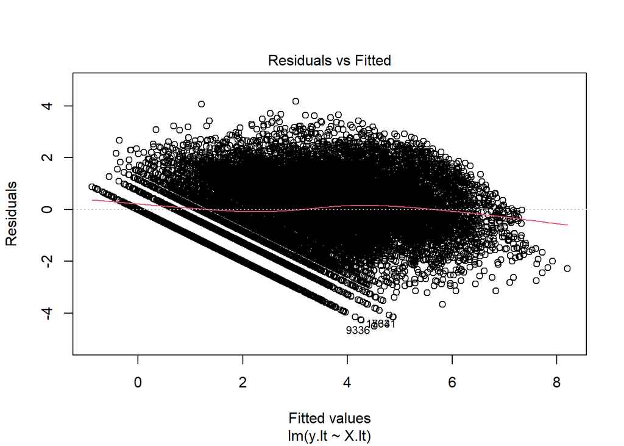

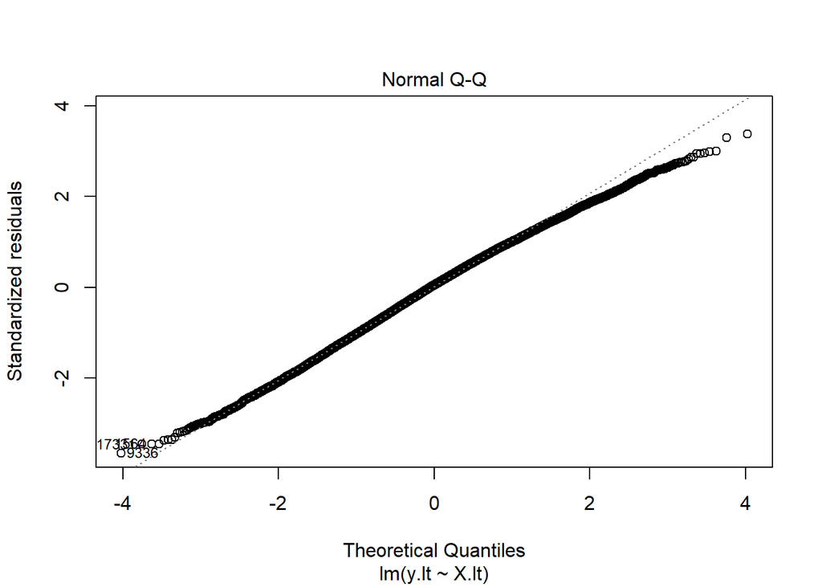

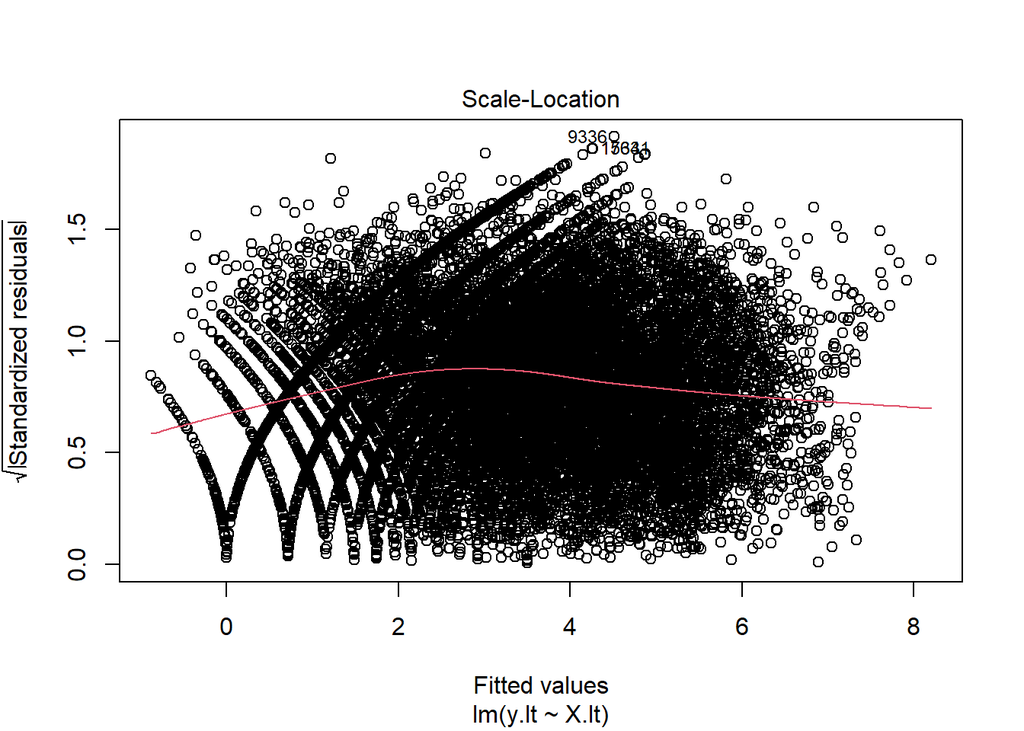

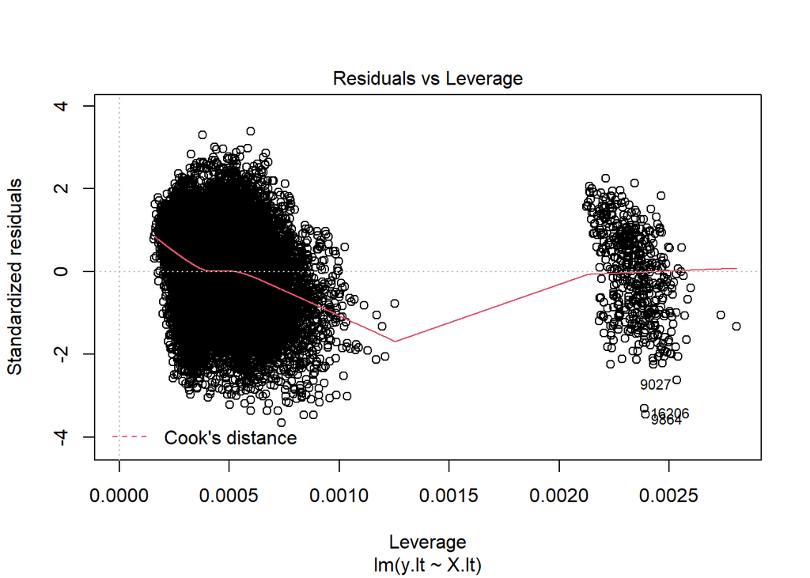

```r
plot(lm(y.lt~X.lt))
```

```r
## PRESS
PRESS(lm(y.lt~X.lt))
```

```
## [1] 26436.79
```

Backwards Selection: All except ‘weathersit’ and ‘windspeed’

### Quadratic, Casual, atemp

```r
x.qa$casual <-(x.qa$casual^lambda.qca-1)/lambda.qca
y.qa <- x.qa$casual
X.qa <- subset(x.qa, select = - c(casual,registered))
X.qa <- as.matrix(X.qa)

## LASSO
cross.validation.qca <- cv.glmnet(X.qa, y.qa, alpha = 1,type.measure = "mse")

optimal.lambda.qca <- cross.validation.qca$lambda.min


lm.lasso.optimal.qca <-glmnet(X.qa, y.qa,
                   lambda = optimal.lambda.qca,
                   alpha = 1, #alpha=1 is the LASSO penalty
                   family = 'gaussian')

coef(lm.lasso.optimal.qca)
```

```
## 18 x 1 sparse Matrix of class "dgCMatrix"
##                      s0
## (Intercept) -2.61801294
## yr           0.29867468
## mnth         0.16937165
## hr           0.42273303
## holiday      0.10983960
## weekday     -0.38358383
## workingday  -0.48434939
## weathersit   0.76872979
## atemp       10.61558874
## hum          0.50309738
## windspeed    1.11503596
## mnth2       -0.01115769
## hr2         -0.01386464
## weekday2     0.06708585
## weathersit2 -0.24128927
## atemp2      -6.26182680
## hum2        -2.07921851
## windspeed2  -2.42865966
```

```r
summary(lm(y.qa~X.qa))
```

```
##
## Call:
## lm(formula = y.qa ~ X.qa)
##
## Residuals:
##     Min      1Q  Median      3Q     Max
## -4.2628 -0.6345  0.0864  0.6851  4.7887
##
## Coefficients:
##                   Estimate Std. Error t value Pr(>|t|)
## (Intercept)     -2.7031096  0.1166333 -23.176  < 2e-16 ***
## X.qayr           0.2987294  0.0163347  18.288  < 2e-16 ***
## X.qamnth         0.1745436  0.0186063   9.381  < 2e-16 ***
## X.qahr           0.4244173  0.0048783  87.000  < 2e-16 ***
## X.qaholiday      0.1507912  0.0597641   2.523   0.0116 *
## X.qaweekday     -0.4253875  0.0350880 -12.123  < 2e-16 ***
## X.qaworkingday  -0.4359713  0.0446172  -9.771  < 2e-16 ***
## X.qaweathersit   0.7900388  0.0804459   9.821  < 2e-16 ***
## X.qaatemp       10.7103119  0.2810788  38.104  < 2e-16 ***
## X.qahum          0.6256131  0.2633012   2.376   0.0175 *
## X.qawindspeed    1.1398406  0.1768999   6.443 1.20e-10 ***
## X.qamnth2       -0.0115607  0.0013501  -8.563  < 2e-16 ***
## X.qahr2         -0.0139316  0.0001986 -70.137  < 2e-16 ***
## X.qaweekday2     0.0739773  0.0057976  12.760  < 2e-16 ***
## X.qaweathersit2 -0.2468745  0.0219064 -11.269  < 2e-16 ***
## X.qaatemp2      -6.3829658  0.2745912 -23.245  < 2e-16 ***
## X.qahum2        -2.1783838  0.2125857 -10.247  < 2e-16 ***
## X.qawindspeed2  -2.4734663  0.3611215  -6.849 7.66e-12 ***
## ---
## Signif. codes:  0 '***' 0.001 '**' 0.01 '*' 0.05 '.' 0.1 ' ' 1
##
## Residual standard error: 1.062 on 17361 degrees of freedom
## Multiple R-squared:  0.7024, Adjusted R-squared:  0.7021
## F-statistic:  2411 on 17 and 17361 DF,  p-value: < 2.2e-16
```

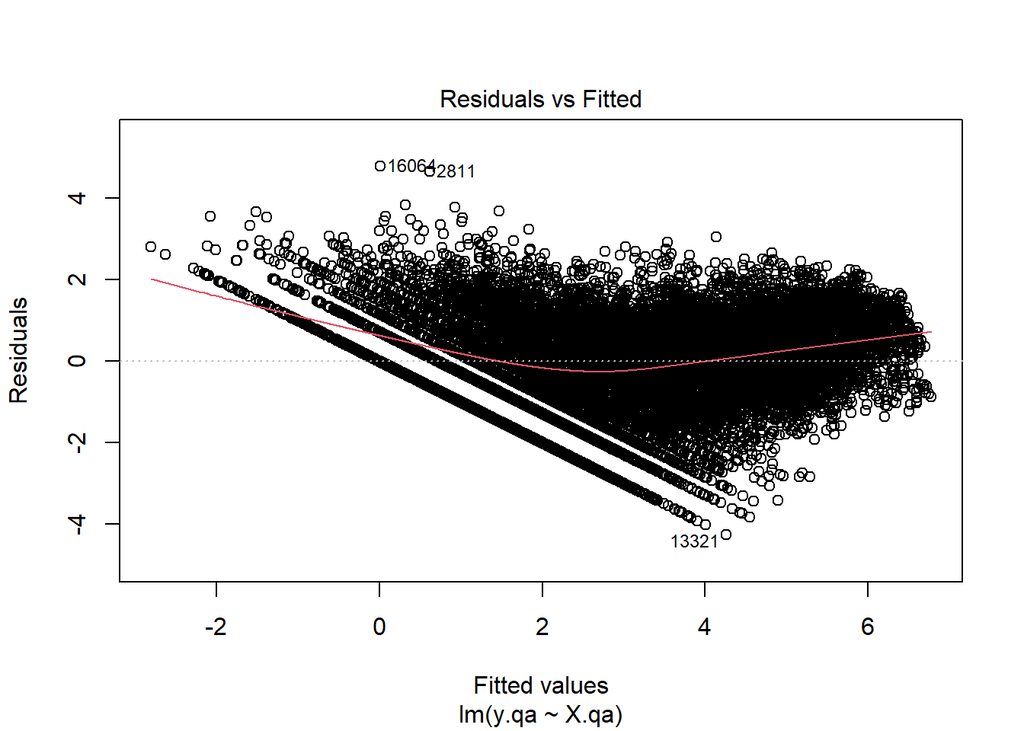

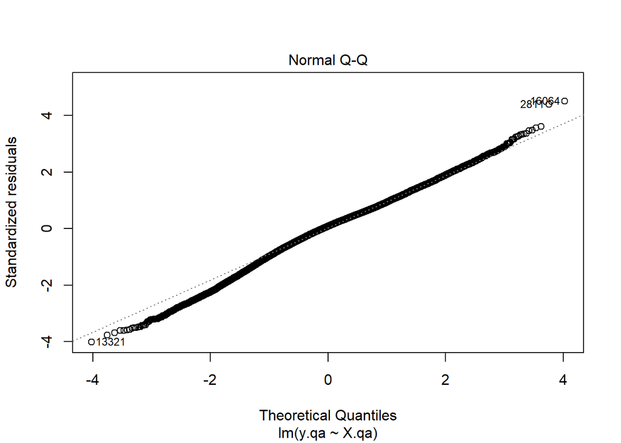

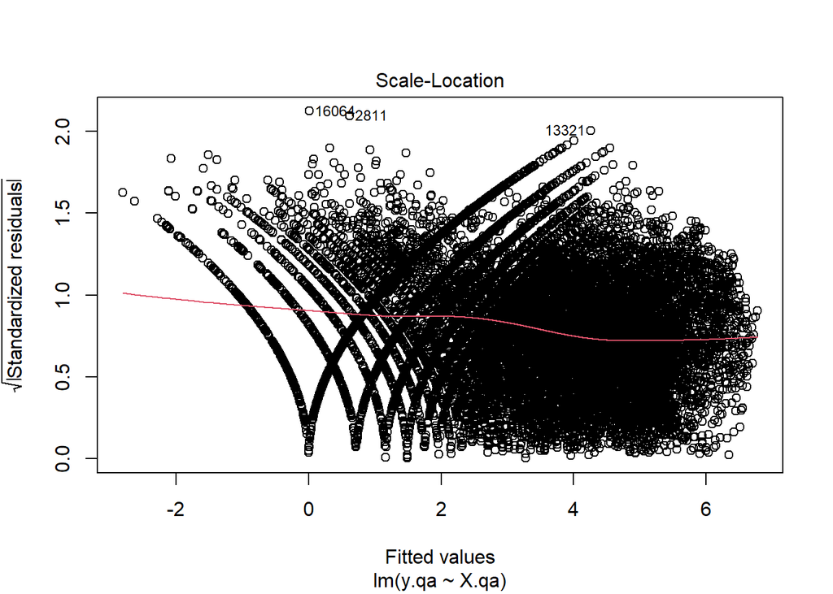

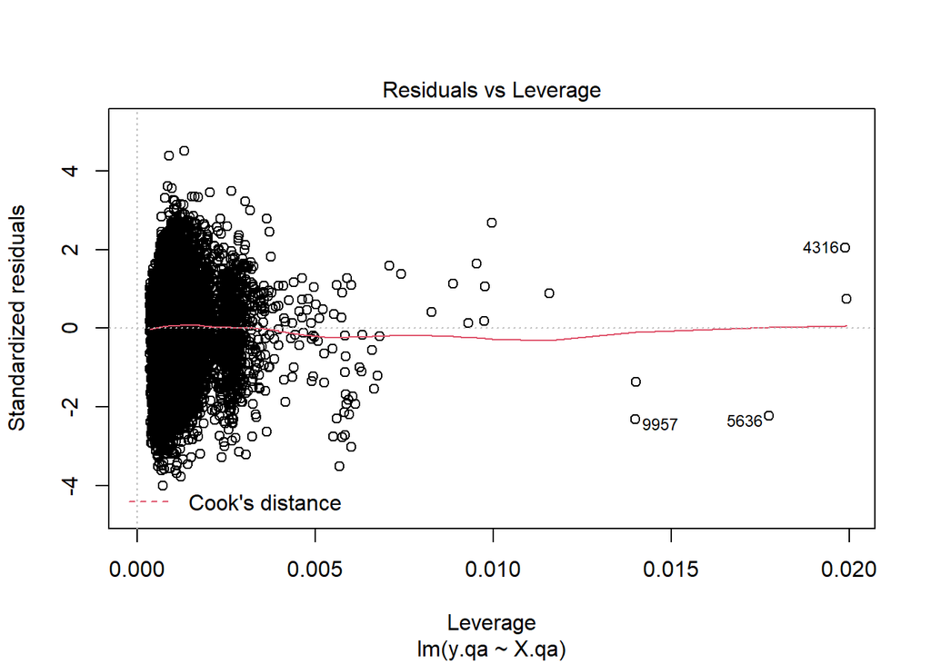

```r
plot(lm(y.qa~X.qa))
```

```r
## No Backwards Selection: All variables are significant to begin with
```

LASSO: All variables are significant

Backwards Selection: All variables are significant

### Quadratic, Casual, temp

```r
x.qt$casual <-(x.qt$casual^lambda.qct-1)/lambda.qct
y.qt <- x.qt$casual
X.qt <- subset(x.qt, select = - c(casual,registered))
X.qt <- as.matrix(X.qt)

## LASSO
cross.validation.qct <- cv.glmnet(X.qt, y.qt, alpha = 1,type.measure = "mse")

optimal.lambda.qct <- cross.validation.qct$lambda.min


lm.lasso.optimal.qct <-glmnet(X.qt, y.qt,
                   lambda = optimal.lambda.qct,
                   alpha = 1, #alpha=1 is the LASSO penalty
                   family = 'gaussian')

coef(lm.lasso.optimal.qct)
```

```
## 18 x 1 sparse Matrix of class "dgCMatrix"
##                      s0
## (Intercept) -2.36041389
## yr           0.28612100
## mnth         0.10973140
## hr           0.42344177
## holiday      0.07807535
## weekday     -0.38459200
## workingday  -0.49142857
## weathersit   0.74069906
## temp        10.17174197
## hum          0.77750473
## windspeed    0.55722249
## mnth2       -0.00685655
## hr2         -0.01390917
## weekday2     0.06691368
## weathersit2 -0.23447545
## temp2       -5.80830052
## hum2        -2.30940408
## windspeed2  -2.15024918
```

```r
summary(lm(y.qt~X.qt))
```

```
##
## Call:
## lm(formula = y.qt ~ X.qt)
##
## Residuals:
##     Min      1Q  Median      3Q     Max
## -4.2823 -0.6279  0.0907  0.6868  4.7835
##
## Coefficients:
##                   Estimate Std. Error t value Pr(>|t|)
## (Intercept)     -2.4417913  0.1121827 -21.766  < 2e-16 ***
## X.qtyr           0.2859821  0.0163646  17.476  < 2e-16 ***
## X.qtmnth         0.1120013  0.0194809   5.749 9.11e-09 ***
## X.qthr           0.4250316  0.0048795  87.106  < 2e-16 ***
## X.qtholiday      0.1209391  0.0597791   2.023 0.043078 *
## X.qtweekday     -0.4287063  0.0350932 -12.216  < 2e-16 ***
## X.qtworkingday  -0.4405024  0.0446204  -9.872  < 2e-16 ***
## X.qtweathersit   0.7667158  0.0804784   9.527  < 2e-16 ***
## X.qttemp        10.2706555  0.2546352  40.335  < 2e-16 ***
## X.qthum          0.8863357  0.2625390   3.376 0.000737 ***
## X.qtwindspeed    0.5858521  0.1767235   3.315 0.000918 ***
## X.qtmnth2       -0.0070500  0.0014114  -4.995 5.94e-07 ***
## X.qthr2         -0.0139737  0.0001987 -70.328  < 2e-16 ***
## X.qtweekday2     0.0741906  0.0057982  12.795  < 2e-16 ***
## X.qtweathersit2 -0.2413600  0.0219154 -11.013  < 2e-16 ***
## X.qttemp2       -5.9143544  0.2295750 -25.762  < 2e-16 ***
## X.qthum2        -2.3976485  0.2114640 -11.338  < 2e-16 ***
## X.qtwindspeed2  -2.2078173  0.3611390  -6.113 9.96e-10 ***
## ---
## Signif. codes:  0 '***' 0.001 '**' 0.01 '*' 0.05 '.' 0.1 ' ' 1
##
## Residual standard error: 1.062 on 17361 degrees of freedom
## Multiple R-squared:  0.7023, Adjusted R-squared:  0.702
## F-statistic:  2410 on 17 and 17361 DF,  p-value: < 2.2e-16
```

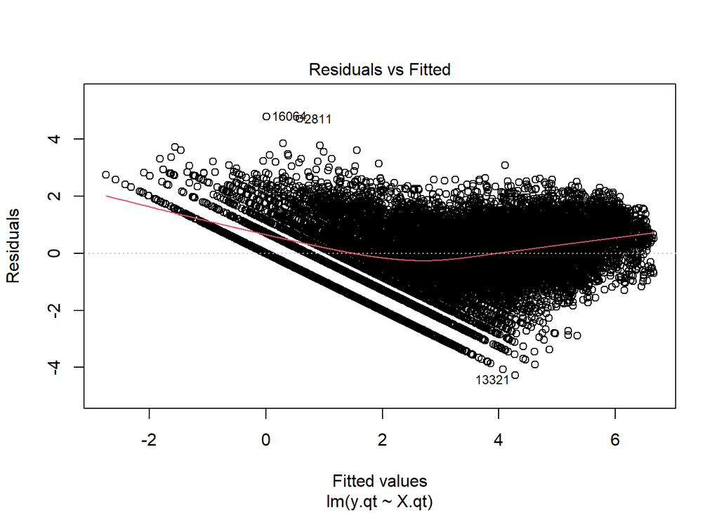

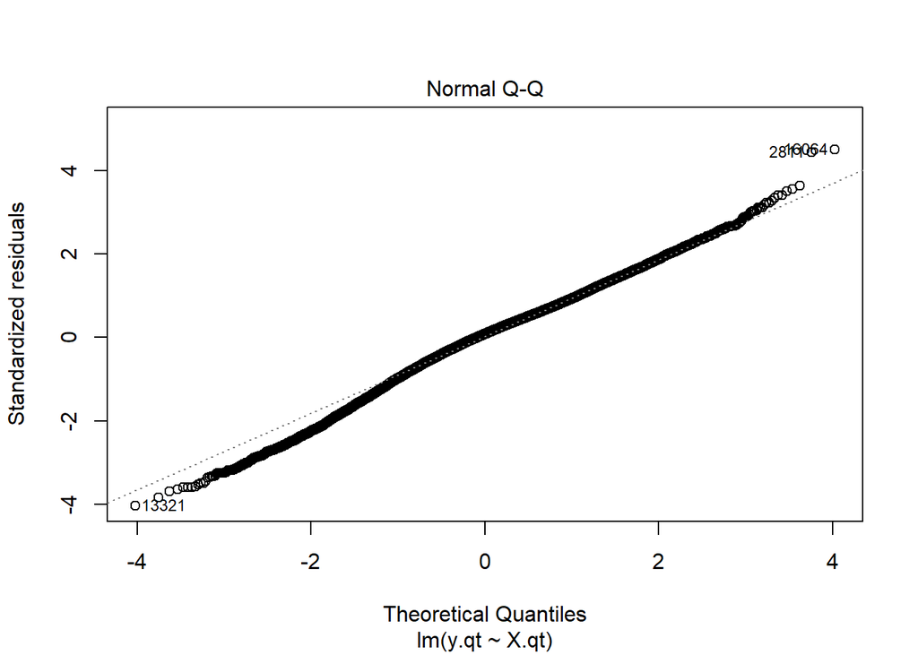

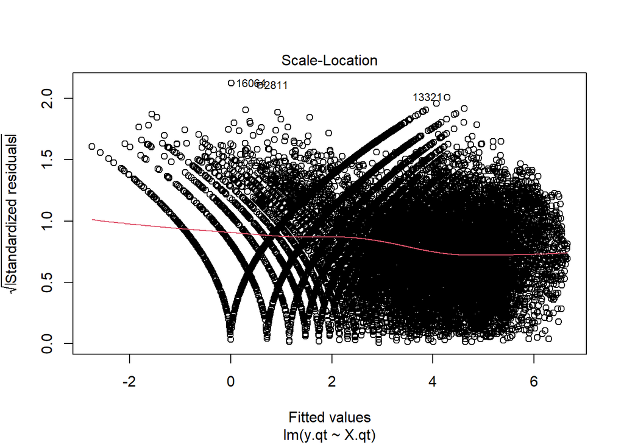

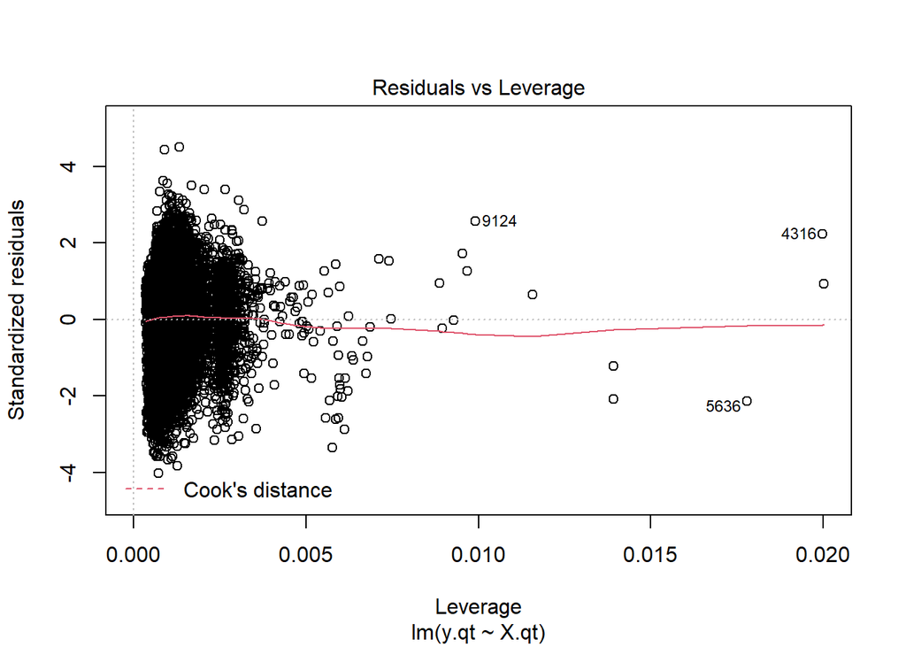

```r
plot(lm(y.qt~X.qt))
```

```r
## No Backwards Selection: All variables are significant to begin with
```

LASSO: All variables are significant

Backwards Selection: All variables are significant

### Linear, Registered, atemp

```r
x.la <- subset(df, select = - c(season,temp))
x.la$casual <- x.la$casual+1
x.la$registered <- x.la$registered+1
x.la$registered <-(x.la$registered^lambda.lra-1)/lambda.lra
y.la <- x.la$registered
X.la <- subset(x.la, select = - c(casual,registered))
X.la <- as.matrix(X.la)

## LASSO
cross.validation.lra <- cv.glmnet(X.la, y.la, alpha = 1,type.measure = "mse")

optimal.lambda.lra <- cross.validation.lra$lambda.min


lm.lasso.optimal.lra <-glmnet(X.la, y.la,
                   lambda = optimal.lambda.lra,
                   alpha = 1, #alpha=1 is the LASSO penalty
                   family = 'gaussian')

coef(lm.lasso.optimal.lra)
```

```
## 11 x 1 sparse Matrix of class "dgCMatrix"
##                      s0
## (Intercept)  3.27754679
## yr           1.52059799
## mnth         0.12306559
## hr           0.26265001
## holiday     -0.51805054
## weekday      0.04608924
## workingday   0.54920978
## weathersit  -0.04048295
## atemp        6.09477897
## hum         -3.87488841
## windspeed    0.93954780
```

```r
## Backwards Selection
X.la<- subset(X.la,select = - weathersit)
summary(lm(y.la~X.la))
```

```
##
## Call:
## lm(formula = y.la ~ X.la)
##
## Residuals:
##     Min      1Q  Median      3Q     Max
## -8.7893 -2.1338 -0.0828  1.9117 10.0905
##
## Coefficients:
##                 Estimate Std. Error t value Pr(>|t|)
## (Intercept)     3.220156   0.145219  22.174  < 2e-16 ***
## X.layr          1.531082   0.045904  33.354  < 2e-16 ***
## X.lamnth        0.125389   0.006928  18.099  < 2e-16 ***
## X.lahr          0.262810   0.003475  75.625  < 2e-16 ***
## X.laholiday    -0.545095   0.141912  -3.841 0.000123 ***
## X.laweekday     0.048521   0.011459   4.234  2.3e-05 ***
## X.laworkingday  0.557224   0.050777  10.974  < 2e-16 ***
## X.laatemp       6.128988   0.138077  44.388  < 2e-16 ***
## X.lahum        -3.961104   0.129973 -30.476  < 2e-16 ***
## X.lawindspeed   0.956328   0.196894   4.857  1.2e-06 ***
## ---
## Signif. codes:  0 '***' 0.001 '**' 0.01 '*' 0.05 '.' 0.1 ' ' 1
##
## Residual standard error: 3.01 on 17369 degrees of freedom
## Multiple R-squared:  0.4552, Adjusted R-squared:  0.455
## F-statistic:  1613 on 9 and 17369 DF,  p-value: < 2.2e-16
```

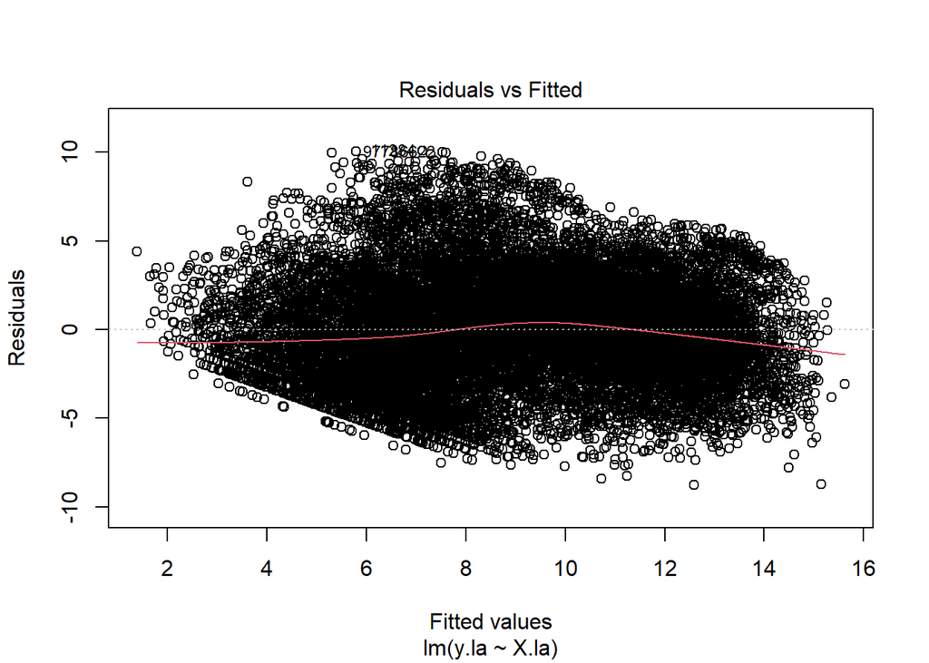

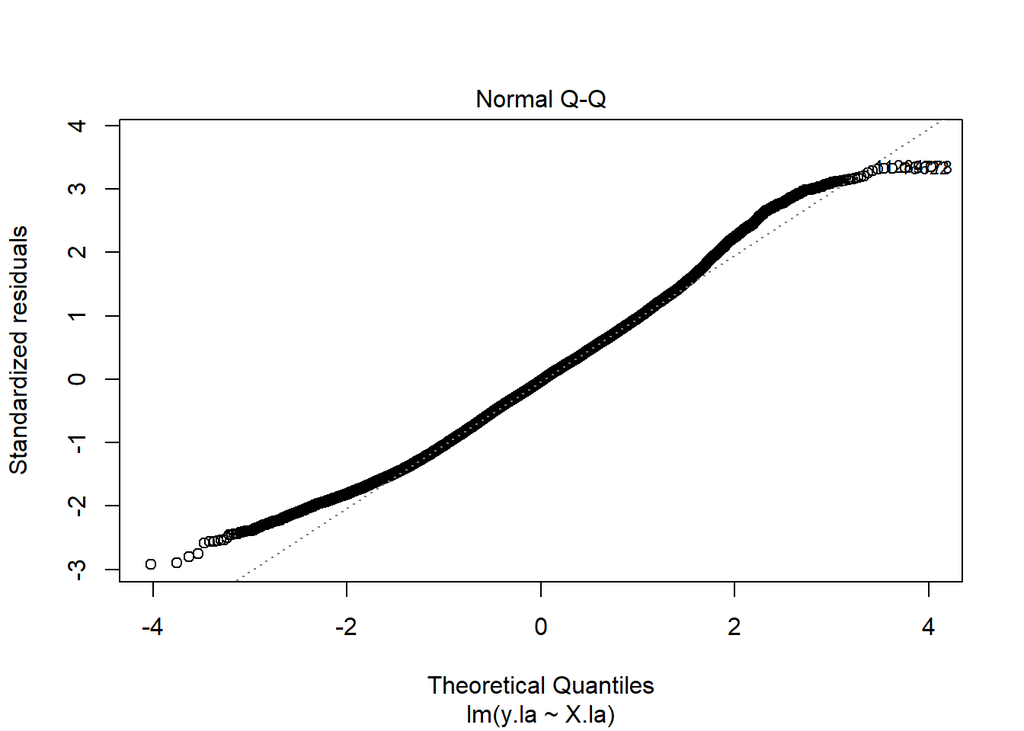

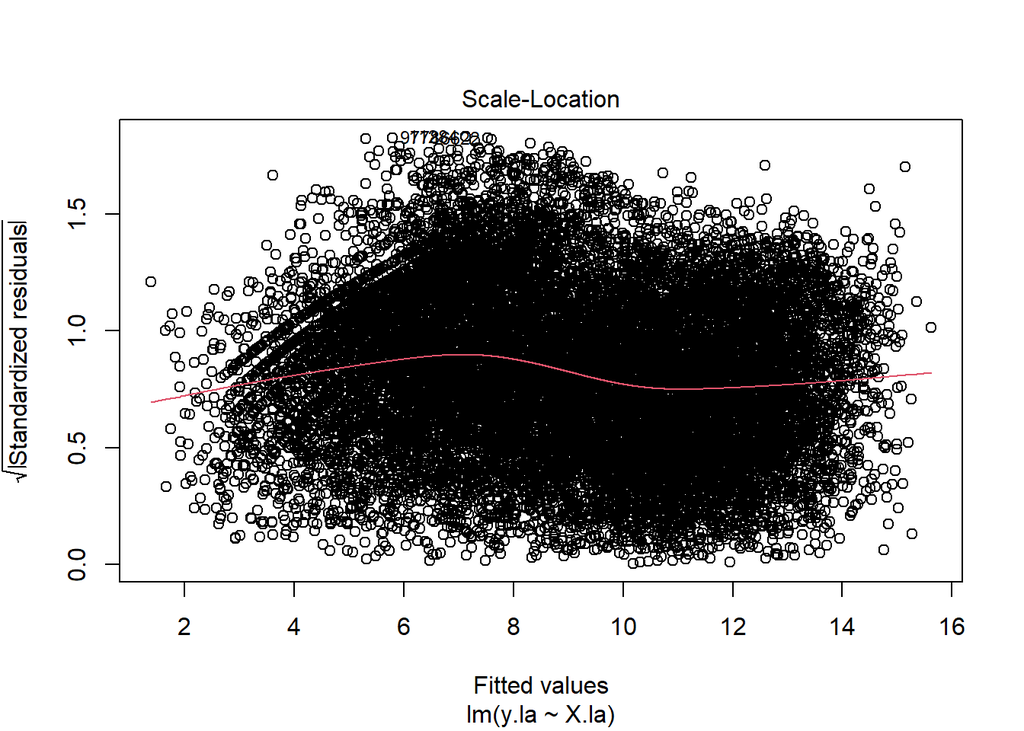

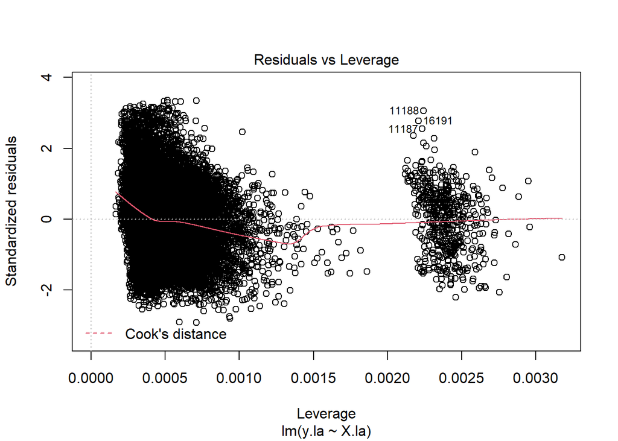

```r
plot(lm(y.la~X.la))
```

```r
## PRESS
PRESS(lm(y.la~X.la))
```

```
## [1] 157545.7
```

LASSO: All variables are significant

Backwards Selection: All except ‘weathersit’

### Linear, Registered, temp

```r
x.lt <- subset(df, select = - c(season,atemp))
x.lt$casual <- x.lt$casual+1
x.lt$registered <- x.lt$registered+1
x.lt$registered <-(x.lt$registered^lambda.lrt-1)/lambda.lrt
y.lt <- x.lt$registered
X.lt <- subset(x.lt, select = - c(casual,registered))
X.lt <- as.matrix(X.lt)

## LASSO
cross.validation.lrt <- cv.glmnet(X.lt, y.lt, alpha = 1,type.measure = "mse")

optimal.lambda.lrt <- cross.validation.lrt$lambda.min


lm.lasso.optimal.lrt <-glmnet(X.lt, y.lt,
                   lambda = optimal.lambda.lrt,
                   alpha = 1, #alpha=1 is the LASSO penalty
                   family = 'gaussian')

coef(lm.lasso.optimal.lrt)
```

```
## 11 x 1 sparse Matrix of class "dgCMatrix"
##                      s0
## (Intercept)  3.54958129
## yr           1.51909793
## mnth         0.12383761
## hr           0.26350641
## holiday     -0.54877549
## weekday      0.04260071
## workingday   0.54633427
## weathersit  -0.05283514
## temp         5.36977247
## hum         -3.81845109
## windspeed    0.62576872
```

```r
## Backwards Selection
X.lt<- subset(X.lt,select = - c(weathersit,windspeed))
summary(lm(y.lt~X.lt))
```

```
##
## Call:
## lm(formula = y.lt ~ X.lt)
##
## Residuals:
##     Min      1Q  Median      3Q     Max
## -8.5630 -2.1449 -0.0697  1.9086 10.1121
##
## Coefficients:
##                 Estimate Std. Error t value Pr(>|t|)
## (Intercept)     3.690065   0.129287  28.542  < 2e-16 ***
## X.ltyr          1.524561   0.045952  33.177  < 2e-16 ***
## X.ltmnth        0.124353   0.006911  17.992  < 2e-16 ***
## X.lthr          0.264324   0.003471  76.161  < 2e-16 ***
## X.ltholiday    -0.575601   0.142109  -4.050 5.13e-05 ***
## X.ltweekday     0.045052   0.011475   3.926 8.66e-05 ***
## X.ltworkingday  0.552612   0.050857  10.866  < 2e-16 ***
## X.lttemp        5.388083   0.123132  43.759  < 2e-16 ***
## X.lthum        -4.029487   0.126078 -31.960  < 2e-16 ***
## ---
## Signif. codes:  0 '***' 0.001 '**' 0.01 '*' 0.05 '.' 0.1 ' ' 1
##
## Residual standard error: 3.015 on 17370 degrees of freedom
## Multiple R-squared:  0.4536, Adjusted R-squared:  0.4533
## F-statistic:  1802 on 8 and 17370 DF,  p-value: < 2.2e-16
```

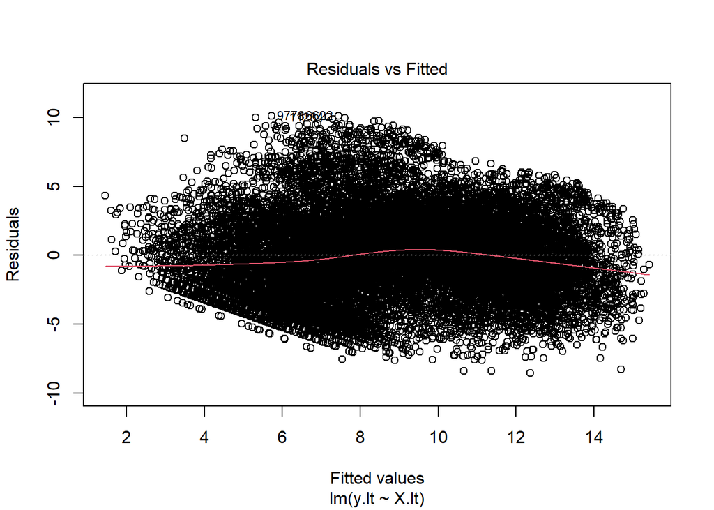

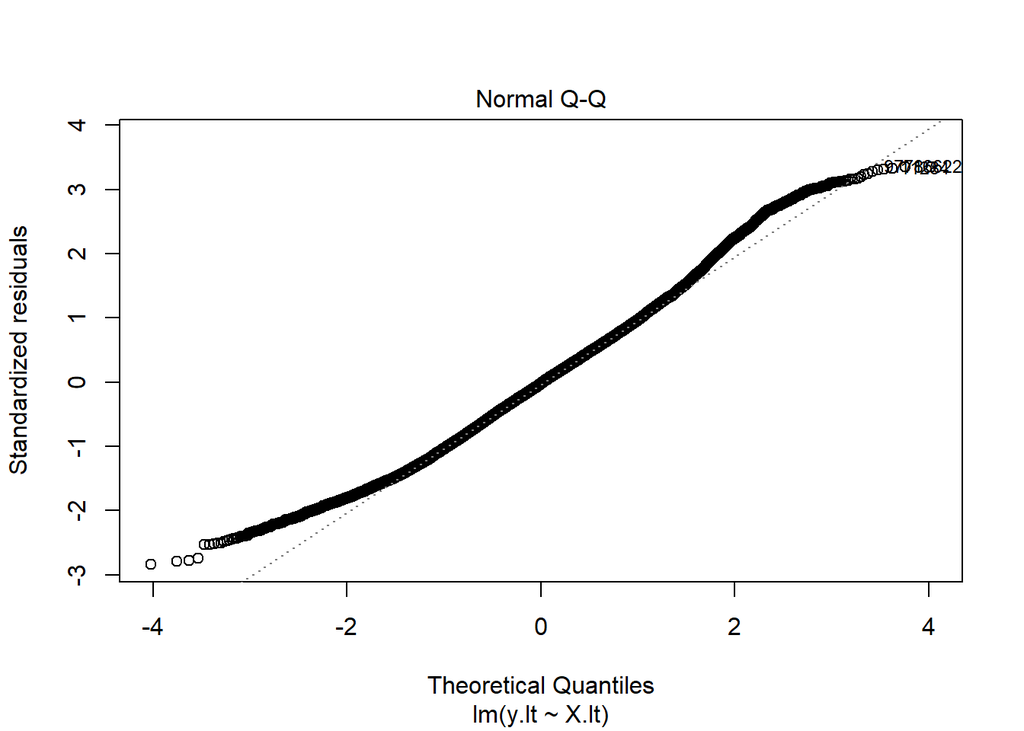

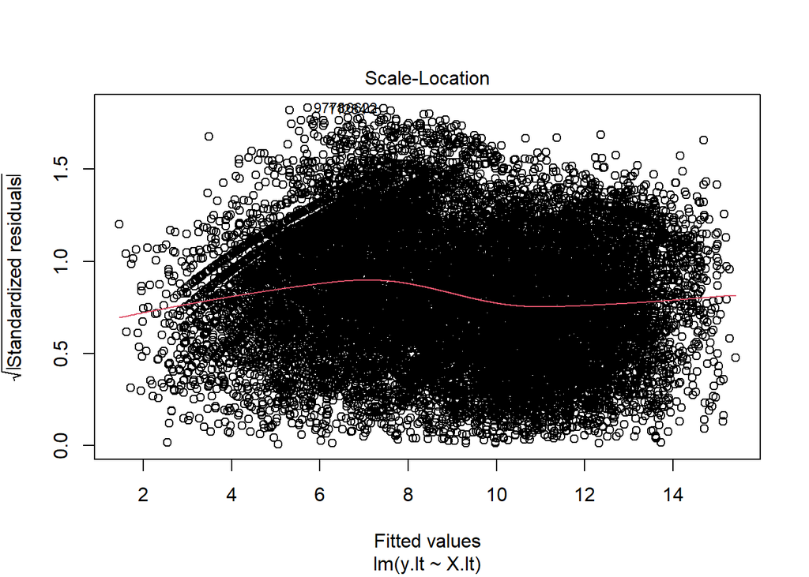

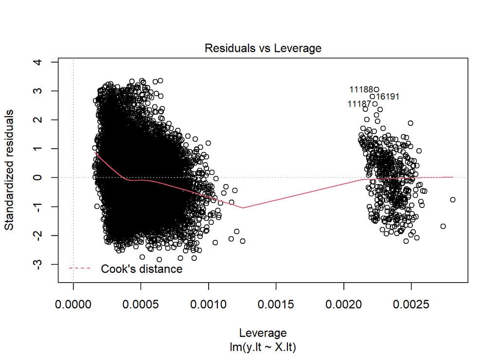

```r
plot(lm(y.lt~X.lt))
```

```r
## PRESS
PRESS(lm(y.lt~X.lt))
```

```
## [1] 158008.8
```

LASSO: All variables are significant

Backwards Selection: All except ‘weathersit’ and ‘windspeed’

### Quadratic, Registered, atemp

```r
x.qa <- subset(df, select = - c(season,temp))
x.qa$casual <- x.qa$casual+1
x.qa$registered <- x.qa$registered+1
x.qa$mnth2 <- x.qa$mnth^2
x.qa$hr2 <- x.qa$hr^2
x.qa$weekday2 <- x.qa$weekday^2
x.qa$weathersit2 <- x.qa$weathersit^2
x.qa$atemp2 <- x.qa$atemp^2
x.qa$hum2 <- x.qa$hum^2
x.qa$windspeed2 <- x.qa$windspeed^2
x.qa$registered <-(x.qa$registered^lambda.qra-1)/lambda.qra
y.qa <- x.qa$registered
X.qa <- subset(x.qa, select = - c(casual,registered))
X.qa <- as.matrix(X.qa)

## LASSO
cross.validation.qra <- cv.glmnet(X.qa, y.qa, alpha = 1,type.measure = "mse")

optimal.lambda.qra <- cross.validation.qra$lambda.min


lm.lasso.optimal.qra <-glmnet(X.qa, y.qa,
                   lambda = optimal.lambda.qra,
                   alpha = 1, #alpha=1 is the LASSO penalty
                   family = 'gaussian')

coef(lm.lasso.optimal.qra)
```

```
## 18 x 1 sparse Matrix of class "dgCMatrix"
##                       s0
## (Intercept) -3.525696531
## yr           1.276406864
## mnth         0.153870282
## hr           0.938441680
## holiday     -0.395071512
## weekday      0.004635810
## workingday   0.500601620
## weathersit   1.251297491
## atemp       10.481772852
## hum          2.801583963
## windspeed    1.927599898
## mnth2       -0.005612006
## hr2         -0.030154644
## weekday2     0.007693661
## weathersit2 -0.432752868
## atemp2      -6.900935264
## hum2        -3.620608989
## windspeed2  -3.993443143
```

```r
## Backwards Selection
X.qa<- subset(X.qa,select = - c(weekday))
summary(lm(y.qa~X.qa))
```

```
##
## Call:
## lm(formula = y.qa ~ X.qa)
##
## Residuals:
##     Min      1Q  Median      3Q     Max
## -6.3209 -1.4539 -0.1576  1.3002  7.4343
##
## Coefficients:
##                   Estimate Std. Error t value Pr(>|t|)
## (Intercept)     -3.7344608  0.2392537 -15.609  < 2e-16 ***
## X.qayr           1.2748702  0.0335298  38.022  < 2e-16 ***
## X.qamnth         0.1542227  0.0381767   4.040 5.37e-05 ***
## X.qahr           0.9411840  0.0100134  93.992  < 2e-16 ***
## X.qaholiday     -0.3915411  0.1039941  -3.765 0.000167 ***
## X.qaworkingday   0.5064935  0.0379880  13.333  < 2e-16 ***
## X.qaweathersit   1.3113874  0.1650547   7.945 2.06e-15 ***
## X.qaatemp       10.8436068  0.5769348  18.795  < 2e-16 ***
## X.qahum          3.0755726  0.5403948   5.691 1.28e-08 ***
## X.qawindspeed    1.9756486  0.3630940   5.441 5.37e-08 ***
## X.qamnth2       -0.0057136  0.0027701  -2.063 0.039164 *
## X.qahr2         -0.0302674  0.0004077 -74.235  < 2e-16 ***
## X.qaweekday2     0.0085198  0.0013723   6.209 5.47e-10 ***
## X.qaweathersit2 -0.4487449  0.0449425  -9.985  < 2e-16 ***
## X.qaatemp2      -7.2843006  0.5636454 -12.924  < 2e-16 ***
## X.qahum2        -3.8456349  0.4362898  -8.814  < 2e-16 ***
## X.qawindspeed2  -4.0755638  0.7412412  -5.498 3.89e-08 ***
## ---
## Signif. codes:  0 '***' 0.001 '**' 0.01 '*' 0.05 '.' 0.1 ' ' 1
##
## Residual standard error: 2.18 on 17362 degrees of freedom
## Multiple R-squared:  0.5958, Adjusted R-squared:  0.5954
## F-statistic:  1600 on 16 and 17362 DF,  p-value: < 2.2e-16
```

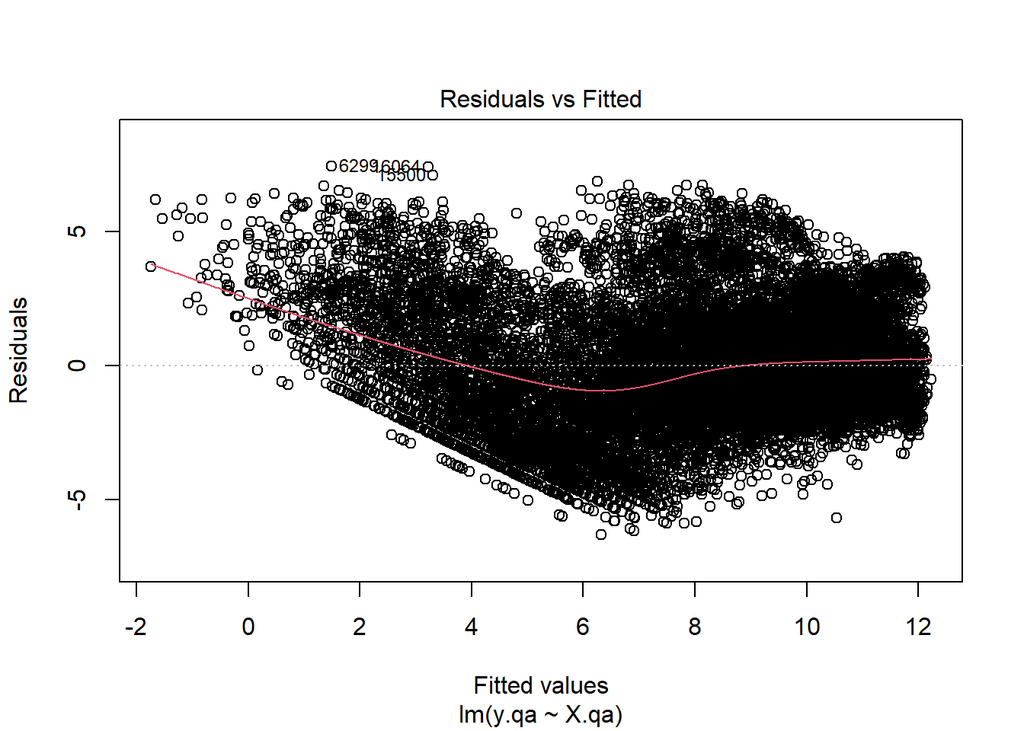

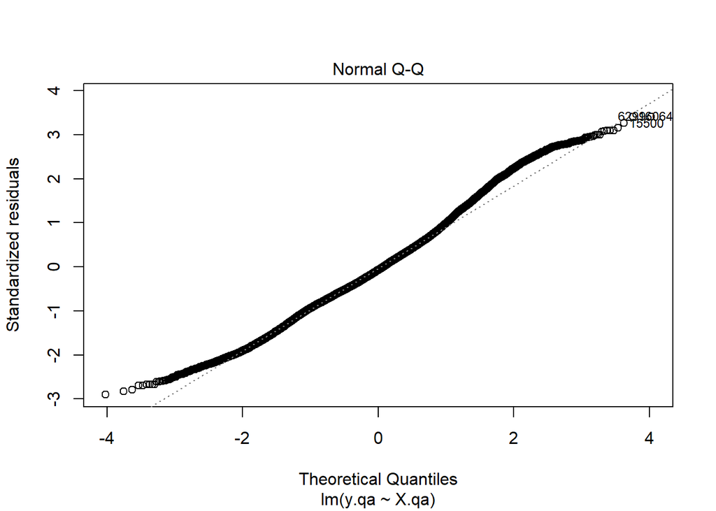

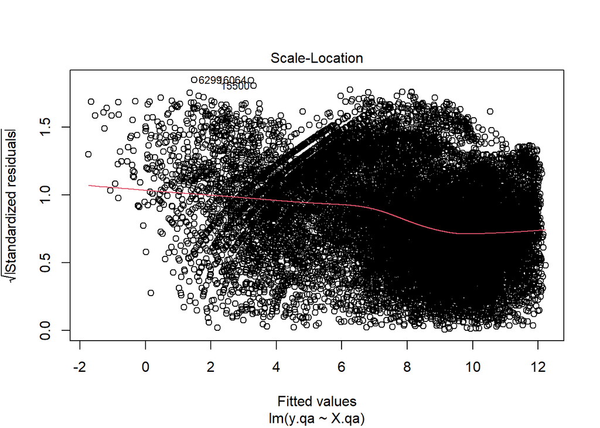

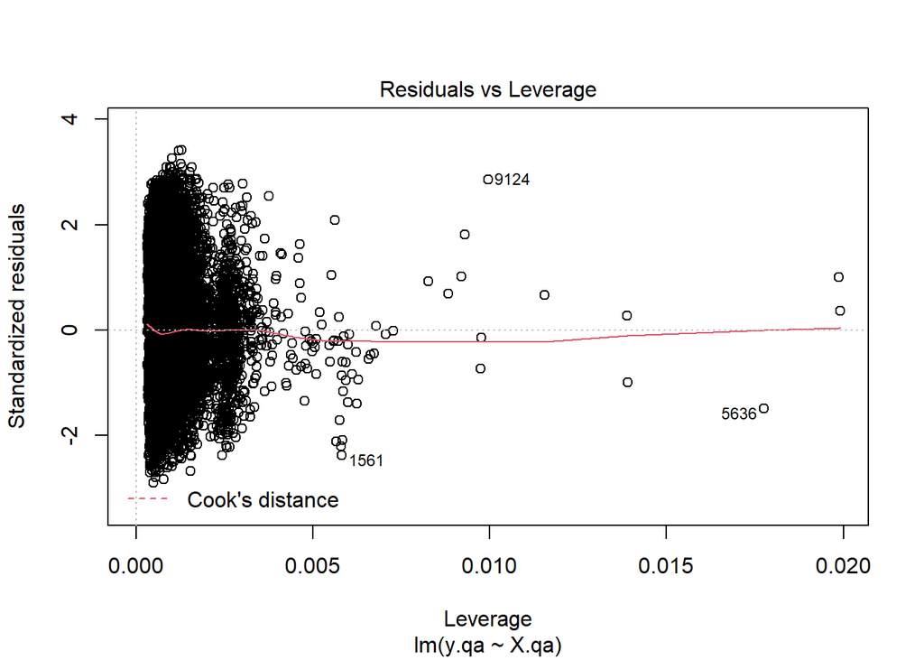

```r
plot(lm(y.qa~X.qa))
```

```r
## PRESS
PRESS(lm(y.qa~X.qa))
```

```
## [1] 82679.51
```

LASSO: All variables are significant

Backwards Selection: All except ‘weekday’

### Quadratic, Registered, temp

```r
x.qt <- subset(df, select = - c(season,atemp))
x.qt$casual <- x.qt$casual+1
x.qt$registered <- x.qt$registered+1
x.qt$mnth2 <- x.qt$mnth^2
x.qt$hr2 <- x.qt$hr^2
x.qt$weekday2 <- x.qt$weekday^2
x.qt$weathersit2 <- x.qt$weathersit^2
x.qt$temp2 <- x.qt$temp^2
x.qt$hum2 <- x.qt$hum^2
x.qt$windspeed2 <- x.qt$windspeed^2
x.qt$registered <-(x.qt$registered^lambda.qrt-1)/lambda.qrt
y.qt <- x.qt$registered
X.qt <- subset(x.qt, select = - c(casual,registered))
X.qt <- as.matrix(X.qt)

## LASSO
cross.validation.qrt <- cv.glmnet(X.qt, y.qt, alpha = 1,type.measure = "mse")

optimal.lambda.qrt <- cross.validation.qrt$lambda.min


lm.lasso.optimal.qrt <-glmnet(X.qt, y.qt,
                   lambda = optimal.lambda.qrt,
                   alpha = 1, #alpha=1 is the LASSO penalty
                   family = 'gaussian')

coef(lm.lasso.optimal.qrt)
```

```
## 18 x 1 sparse Matrix of class "dgCMatrix"
##                       s0
## (Intercept) -3.228059150
## yr           1.264927039
## mnth         0.100308859
## hr           0.938850849
## holiday     -0.423043008
## weekday      0.005316758
## workingday   0.492533368
## weathersit   1.213639636
## temp         9.918784592
## hum          2.958333527
## windspeed    1.381032839
## mnth2       -0.001732016
## hr2         -0.030187002
## weekday2     0.007296286
## weathersit2 -0.423021469
## temp2       -6.232310167
## hum2        -3.761266850
## windspeed2  -3.695251488
```

```r
## Backwards Selection
X.qt<- subset(X.qt,select = - c(weekday,mnth2))
summary(lm(y.qt~X.qt))
```

```
##
## Call:
## lm(formula = y.qt ~ X.qt)
##
## Residuals:
##     Min      1Q  Median      3Q     Max
## -6.3815 -1.4480 -0.1568  1.2977  7.4170
##
## Coefficients:
##                   Estimate Std. Error t value Pr(>|t|)
## (Intercept)     -3.4116668  0.2289196 -14.903  < 2e-16 ***
## X.qtyr           1.2619291  0.0334584  37.716  < 2e-16 ***
## X.qtmnth         0.0755790  0.0051321  14.727  < 2e-16 ***
## X.qthr           0.9409883  0.0099062  94.990  < 2e-16 ***
## X.qtholiday     -0.4234520  0.1038672  -4.077 4.59e-05 ***
## X.qtworkingday   0.4987760  0.0379787  13.133  < 2e-16 ***
## X.qtweathersit   1.2852722  0.1646235   7.807 6.17e-15 ***
## X.qttemp        10.3533588  0.4683430  22.106  < 2e-16 ***
## X.qthum          3.1999846  0.5378473   5.950 2.74e-09 ***
## X.qtwindspeed    1.4513542  0.3626551   4.002 6.31e-05 ***
## X.qthr2         -0.0302863  0.0004055 -74.682  < 2e-16 ***
## X.qtweekday2     0.0082658  0.0013719   6.025 1.72e-09 ***
## X.qtweathersit2 -0.4424342  0.0448410  -9.867  < 2e-16 ***
## X.qttemp2       -6.5813102  0.4614056 -14.264  < 2e-16 ***
## X.qthum2        -3.9564001  0.4335076  -9.126  < 2e-16 ***
## X.qtwindspeed2  -3.8481233  0.7408615  -5.194 2.08e-07 ***
## ---
## Signif. codes:  0 '***' 0.001 '**' 0.01 '*' 0.05 '.' 0.1 ' ' 1
##
## Residual standard error: 2.18 on 17363 degrees of freedom
## Multiple R-squared:  0.5957, Adjusted R-squared:  0.5954
## F-statistic:  1706 on 15 and 17363 DF,  p-value: < 2.2e-16
```

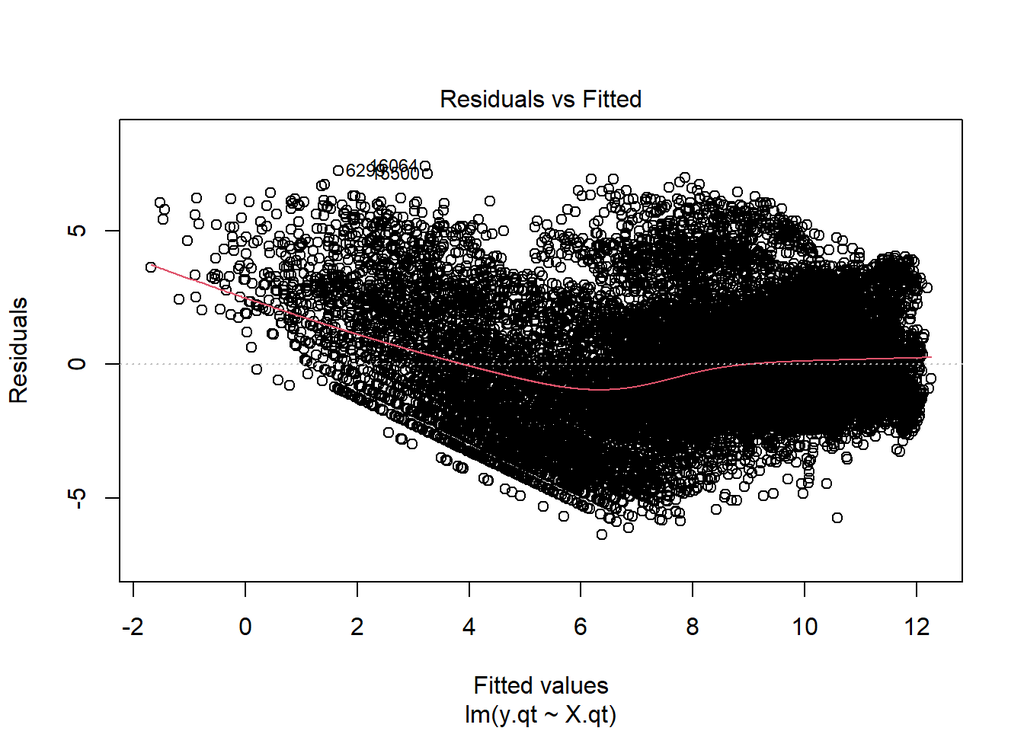

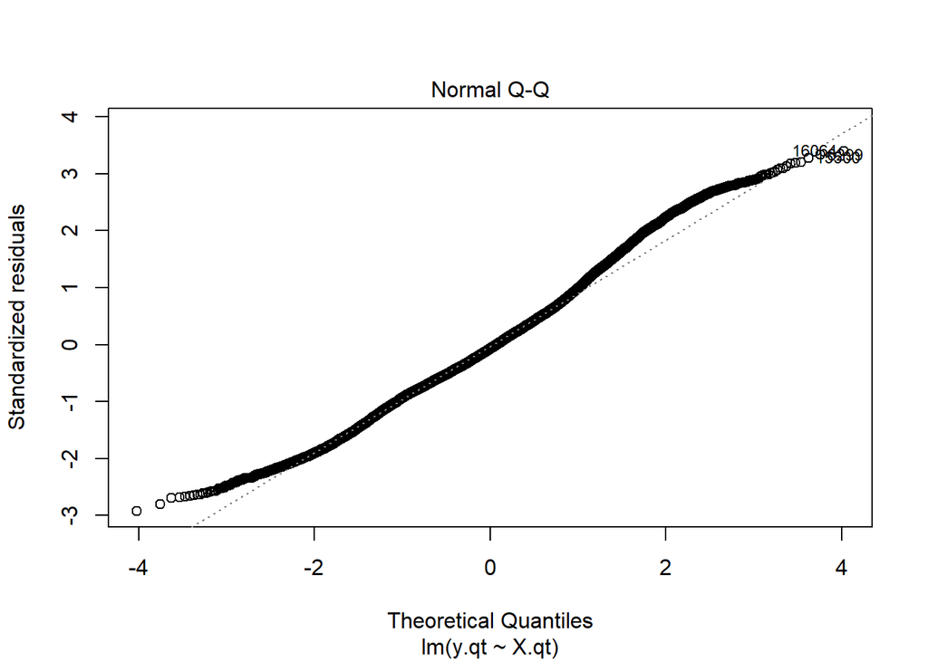

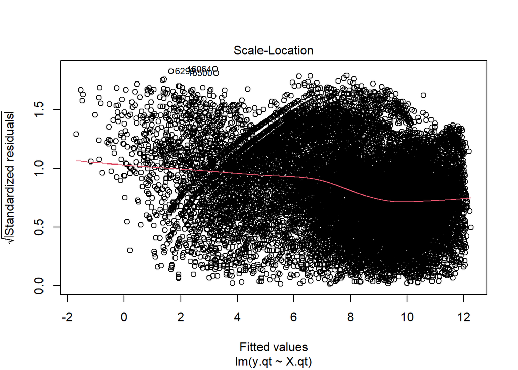

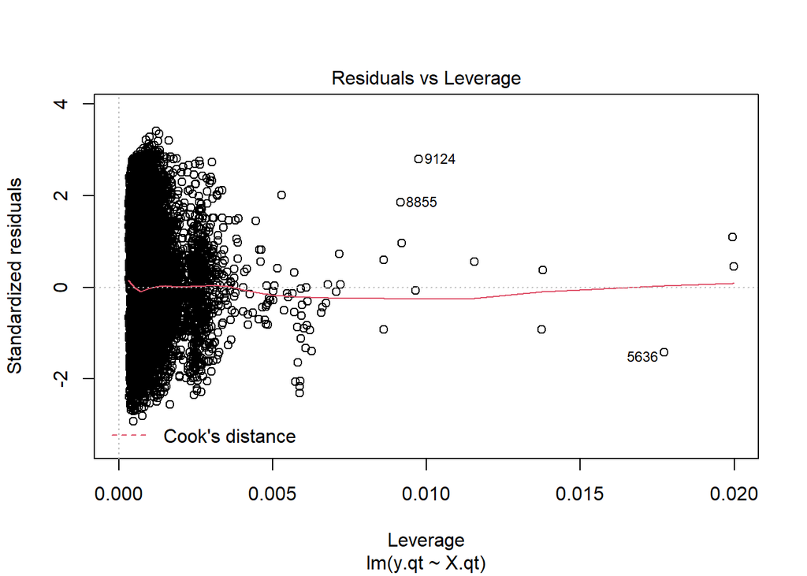

```r
plot(lm(y.qt~X.qt))
```

```r
## PRESS
PRESS(lm(y.qt~X.qt))
```

```
## [1] 82683.47
```

LASSO: All variables are significant

Backwards Selection: All except ‘weekday’ and ‘mnth2’